# Ds 6372 Project 2

Muskaan Mahes

## loading in dataset and libraries

```r
library(aplore3)
library(tidyverse)
bone = glow_bonemed
glimpse(bone)
```

```
## Rows: 500
## Columns: 18
## $ sub_id     <int> 1, 2, 3, 4, 5, 6, 7, 8, 9, 10, 11, 12, 13, 14, 15, 16, 17, …
## $ site_id    <int> 1, 4, 6, 6, 1, 5, 5, 1, 1, 4, 6, 1, 6, 1, 1, 3, 4, 4, 3, 6,…
## $ phy_id     <int> 14, 284, 305, 309, 37, 299, 302, 36, 8, 282, 315, 34, 315, …
## $ priorfrac  <fct> No, No, Yes, No, No, Yes, No, Yes, Yes, No, No, No, No, No,…
## $ age        <int> 62, 65, 88, 82, 61, 67, 84, 82, 86, 58, 67, 56, 59, 72, 64,…
## $ weight     <dbl> 70.3, 87.1, 50.8, 62.1, 68.0, 68.0, 50.8, 40.8, 62.6, 63.5,…
## $ height     <int> 158, 160, 157, 160, 152, 161, 150, 153, 156, 166, 153, 167,…
## $ bmi        <dbl> 28.16055, 34.02344, 20.60936, 24.25781, 29.43213, 26.23356,…
## $ premeno    <fct> No, No, No, No, No, No, No, No, No, No, No, No, No, No, Yes…
## $ momfrac    <fct> No, No, Yes, No, No, No, No, No, No, No, Yes, No, No, No, N…
## $ armassist  <fct> No, No, Yes, No, No, No, No, No, No, No, No, Yes, No, Yes, …
## $ smoke      <fct> No, No, No, No, No, Yes, No, No, No, No, Yes, Yes, Yes, No,…
## $ raterisk   <fct> Same, Same, Less, Less, Same, Same, Less, Same, Same, Less,…
## $ fracscore  <int> 1, 2, 11, 5, 1, 4, 6, 7, 7, 0, 4, 3, 1, 5, 1, 4, 2, 2, 7, 2…
## $ fracture   <fct> No, No, No, No, No, No, No, No, No, No, No, No, No, No, No,…
## $ bonemed    <fct> No, No, No, No, No, No, No, Yes, No, No, No, No, No, No, No…
## $ bonemed_fu <fct> No, No, No, No, No, No, No, Yes, No, No, No, No, No, No, No…
## $ bonetreat  <fct> No, No, No, No, No, No, No, Yes, No, No, No, No, No, No, No…
```

```r
summary(bone)
```

```
##      sub_id         site_id          phy_id       priorfrac      age
##  Min.   :  1.0   Min.   :1.000   Min.   :  1.00   No :374   Min.   :55.00
##  1st Qu.:125.8   1st Qu.:2.000   1st Qu.: 57.75   Yes:126   1st Qu.:61.00
##  Median :250.5   Median :3.000   Median :182.50             Median :67.00
##  Mean   :250.5   Mean   :3.436   Mean   :178.55             Mean   :68.56
##  3rd Qu.:375.2   3rd Qu.:5.000   3rd Qu.:298.00             3rd Qu.:76.00
##  Max.   :500.0   Max.   :6.000   Max.   :325.00             Max.   :90.00
##      weight           height           bmi        premeno   momfrac   armassist
##  Min.   : 39.90   Min.   :134.0   Min.   :14.88   No :403   No :435   No :312
##  1st Qu.: 59.90   1st Qu.:157.0   1st Qu.:23.27   Yes: 97   Yes: 65   Yes:188
##  Median : 68.00   Median :161.5   Median :26.42
##  Mean   : 71.82   Mean   :161.4   Mean   :27.55
##  3rd Qu.: 81.30   3rd Qu.:165.0   3rd Qu.:30.79
##  Max.   :127.00   Max.   :199.0   Max.   :49.08
##  smoke        raterisk     fracscore      fracture  bonemed   bonemed_fu
##  No :465   Less   :167   Min.   : 0.000   No :375   No :371   No :361
##  Yes: 35   Same   :186   1st Qu.: 2.000   Yes:125   Yes:129   Yes:139
##            Greater:147   Median : 3.000
##                          Mean   : 3.698
##                          3rd Qu.: 5.000
##                          Max.   :11.000
##  bonetreat
##  No :382
##  Yes:118
##
##
##
##
```

```r
?glow_bonemed
```

# Data preparation: checking structure & missing values

```r
#checking the raw categories
bone %>%
  select(
    fracture, priorfrac, premeno, momfrac, armassist, smoke, raterisk, bonemed, bonemed_fu, bonetreat
  ) %>%
  map(~table(.x, useNA = "ifany"))
```

```
## $fracture
## .x
##  No Yes
## 375 125
##
## $priorfrac
## .x
##  No Yes
## 374 126
##
## $premeno
## .x
##  No Yes
## 403  97
##
## $momfrac
## .x
##  No Yes
## 435  65
##
## $armassist
## .x
##  No Yes
## 312 188
##
## $smoke
## .x
##  No Yes
## 465  35
##
## $raterisk
## .x
##    Less    Same Greater
##     167     186     147
##
## $bonemed
## .x
##  No Yes
## 371 129
##
## $bonemed_fu
## .x
##  No Yes
## 361 139
##
## $bonetreat
## .x
##  No Yes
## 382 118
```

```r
#checking for missing values
colSums(is.na(bone))
```

```
##     sub_id    site_id     phy_id  priorfrac        age     weight     height
##          0          0          0          0          0          0          0
##        bmi    premeno    momfrac  armassist      smoke   raterisk  fracscore
##          0          0          0          0          0          0          0
##   fracture    bonemed bonemed_fu  bonetreat
##          0          0          0          0
```

```r
#IQR of continuous variables
summary(
  bone %>%
    select(age, weight, height, bmi, fracscore)
)
```

```
##       age            weight           height           bmi
##  Min.   :55.00   Min.   : 39.90   Min.   :134.0   Min.   :14.88
##  1st Qu.:61.00   1st Qu.: 59.90   1st Qu.:157.0   1st Qu.:23.27
##  Median :67.00   Median : 68.00   Median :161.5   Median :26.42
##  Mean   :68.56   Mean   : 71.82   Mean   :161.4   Mean   :27.55
##  3rd Qu.:76.00   3rd Qu.: 81.30   3rd Qu.:165.0   3rd Qu.:30.79
##  Max.   :90.00   Max.   :127.00   Max.   :199.0   Max.   :49.08
##    fracscore
##  Min.   : 0.000
##  1st Qu.: 2.000
##  Median : 3.000
##  Mean   : 3.698
##  3rd Qu.: 5.000
##  Max.   :11.000
```

removed boneTreat because it is about medication status up to enrollement and prior treatment

OUTPUT: - no missing values

continuous variables ranges: age: 55-90 years BMI: 14.88-49.08 Fracture score: 0-11

## Developing model and redefining reference levels

```r
set.seed(1234)

#including variables that would identify patient risk factors
bone_model = bone %>%
  select(
    fracture,
    priorfrac,
    age,
    weight,
    height,
    bmi,
    premeno,
    momfrac,
    armassist,
    smoke,
    raterisk,
    fracscore,
    bonemed
  ) %>%
  mutate(
    fracture = relevel(factor(fracture), ref = "No"), #ensures that "No" is the reference outcome
    across(
      c(
        priorfrac, premeno, momfrac, armassist, smoke, bonemed
      ),
      ~ relevel(factor(.x), ref = "No")
    ),
    raterisk = factor( #reference category for preceieved fracture risk
      raterisk,
      levels = c("Less", "Same", "Greater")
    )
  )

glimpse(bone_model)
```

```
## Rows: 500
## Columns: 13
## $ fracture  <fct> No, No, No, No, No, No, No, No, No, No, No, No, No, No, No, …
## $ priorfrac <fct> No, No, Yes, No, No, Yes, No, Yes, Yes, No, No, No, No, No, …
## $ age       <int> 62, 65, 88, 82, 61, 67, 84, 82, 86, 58, 67, 56, 59, 72, 64, …
## $ weight    <dbl> 70.3, 87.1, 50.8, 62.1, 68.0, 68.0, 50.8, 40.8, 62.6, 63.5, …
## $ height    <int> 158, 160, 157, 160, 152, 161, 150, 153, 156, 166, 153, 167, …
## $ bmi       <dbl> 28.16055, 34.02344, 20.60936, 24.25781, 29.43213, 26.23356, …
## $ premeno   <fct> No, No, No, No, No, No, No, No, No, No, No, No, No, No, Yes,…
## $ momfrac   <fct> No, No, Yes, No, No, No, No, No, No, No, Yes, No, No, No, No…
## $ armassist <fct> No, No, Yes, No, No, No, No, No, No, No, No, Yes, No, Yes, N…
## $ smoke     <fct> No, No, No, No, No, Yes, No, No, No, No, Yes, Yes, Yes, No, …
## $ raterisk  <fct> Same, Same, Less, Less, Same, Same, Less, Same, Same, Less, …
## $ fracscore <int> 1, 2, 11, 5, 1, 4, 6, 7, 7, 0, 4, 3, 1, 5, 1, 4, 2, 2, 7, 2,…
## $ bonemed   <fct> No, No, No, No, No, No, No, Yes, No, No, No, No, No, No, No,…
```

## Train validation split

```r
library(rsample)
set.seed(1234)


bone_split = initial_split(
  bone_model,
  prop = 0.75,
  strata = fracture
)


bone_train = training(bone_split)
bone_test = testing(bone_split)

dim(bone_train)
```

```
## [1] 374  13
```

```r
dim(bone_test)
```

```
## [1] 126  13
```

```r
bind_rows(
  bone_train %>%  mutate(dataset = "Training"),
  bone_test %>%  mutate(dataset = "Validation")
) %>%
  count(dataset, fracture) %>%
  group_by(dataset) %>%
  mutate(
    proportion = n / sum(n),
    percent = scales::percent(proportion, accuracy = 0.1)
  ) %>%
  ungroup()
```

| dataset | fracture | n | proportion | percent |
| --- | --- | --- | --- | --- |
| Training | No | 281 | 0.7513369 | 75.1% |
| Training | Yes | 93 | 0.2486631 | 24.9% |
| Validation | No | 94 | 0.7460317 | 74.6% |
| Validation | Yes | 32 | 0.2539683 | 25.4% |

```r
#checking for imbalance
bind_rows(
  bone_train %>%
    summarise(
      dataset = "Training",
      n = n(),
      fracture_rate = mean(fracture == "Yes"),
      mean_age = mean(age),
      mean_bmi = mean(bmi),
      mean_fracscore = mean(fracscore)
    ),
  bone_test %>%
    summarise(
      dataset = "Validation",
      n = n(),
      fracture_rate = mean(fracture == "Yes"),
      mean_age = mean(age),
      mean_bmi = mean(bmi),
      mean_fracscore = mean(fracscore)
    )
)
```

| dataset | n | fracture_rate | mean_age | mean_bmi | mean_fracscore |
| --- | --- | --- | --- | --- | --- |
| Training | 374 | 0.2486631 | 68.58021 | 27.47364 | 3.740642 |
| Validation | 126 | 0.2539683 | 68.50794 | 27.78871 | 3.571429 |

## summary of training data

```r
library(tidyverse)

#continuous variable
continuous_summary = bone_train %>%
  group_by(fracture) %>%
  summarise(
    across(
      c(age, weight, height, bmi, fracscore),
      list(
        mean = ~ mean(.x, na.rm = TRUE),
        sd = ~ sd(.x, na.rm = TRUE),
        median = ~ median(.x, na.rm = TRUE),
        q1 = ~ quantile(.x, 0.25, na.rm = TRUE),
        q3 = ~ quantile(.x, 0.75, na.rm = TRUE)
      ),
      .names = "{.col}_{.fn}"
    ),
    .groups = "drop"
  )

continuous_summary
```

| fracture | age_mean | age_sd | age_median | age_q1 | age_q3 | weight_mean | weight_sd | weight_median | weight_q1 | weight_q3 | height_mean | height_sd | height_median | height_q1 | height_q3 | bmi_mean | bmi_sd | bmi_median | bmi_q1 | bmi_q3 | fracscore_mean | fracscore_sd | fracscore_median | fracscore_q1 | fracscore_q3 |
| --- | --- | --- | --- | --- | --- | --- | --- | --- | --- | --- | --- | --- | --- | --- | --- | --- | --- | --- | --- | --- | --- | --- | --- | --- | --- |
| No | 67.55160 | 8.610107 | 66 | 60 | 75 | 71.97936 | 16.39976 | 68.5 | 59.9 | 81.6 | 161.8043 | 5.729695 | 162 | 158 | 166 | 27.45098 | 5.961089 | 26.36709 | 23.31759 | 30.36423 | 3.362989 | 2.379207 | 3 | 2 | 5 |
| Yes | 71.68817 | 9.693093 | 72 | 63 | 80 | 70.59677 | 15.96019 | 68.0 | 59.9 | 78.9 | 160.0645 | 6.920050 | 160 | 155 | 165 | 27.54210 | 5.833904 | 26.40716 | 23.04688 | 31.09282 | 4.881720 | 2.599538 | 5 | 3 | 7 |

```r
#categorical variable
categorical_summary = bone_train %>%
  pivot_longer(
    cols = c(
      priorfrac,
      premeno,
      momfrac,
      armassist,
      smoke,
      raterisk,
      bonemed
    ),
    names_to = "variable",
    values_to = "category"
  ) |>
  count(variable, category, fracture) |>
  group_by(variable, fracture) |>
  mutate(
    percent = 100 * n / sum(n),
    `n (%)` = sprintf("%d (%.1f%%)", n, percent)
  ) |>
  ungroup() |>
  select(
    variable,
    category,
    fracture,
    `n (%)`
  )

categorical_summary
```

| variable | category | fracture | n (%) |
| --- | --- | --- | --- |
| armassist | No | No | 184 (65.5%) |
| armassist | No | Yes | 43 (46.2%) |
| armassist | Yes | No | 97 (34.5%) |
| armassist | Yes | Yes | 50 (53.8%) |
| bonemed | No | No | 218 (77.6%) |
| bonemed | No | Yes | 62 (66.7%) |
| bonemed | Yes | No | 63 (22.4%) |
| bonemed | Yes | Yes | 31 (33.3%) |
| momfrac | No | No | 254 (90.4%) |
| momfrac | No | Yes | 76 (81.7%) |

[output cut: 20 more lines]

## plot the training outcome prevalence

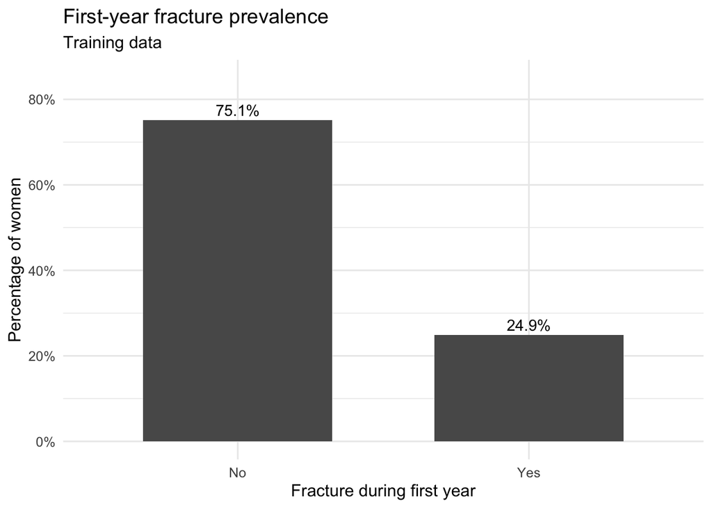

```r
bone_train %>%
  count(fracture) %>%
  mutate(
    proportion = n / sum(n)
  ) %>%
  ggplot(aes(x = fracture, y = proportion)) +
  geom_col(width = 0.65) +
  geom_text(
    aes(
      label = scales::percent(
        proportion,
        accuracy = 0.1
      )
    ),
    vjust = -0.4
  ) +
  scale_y_continuous(
    labels = scales::percent,
    limits = c(0, 0.85)
  ) +
  labs(
    title = "First-year fracture prevalence",
    subtitle = "Training data",
    x = "Fracture during first year",
    y = "Percentage of women"
  ) +
  theme_minimal(base_size = 12)
```

One-quarter of the women experience a fracture during the 1st year. Because fractures are less common than non-fractures, sensitivity may eventually be more informative than overall accuracy when evaluating prediction models.

## continuous predictor

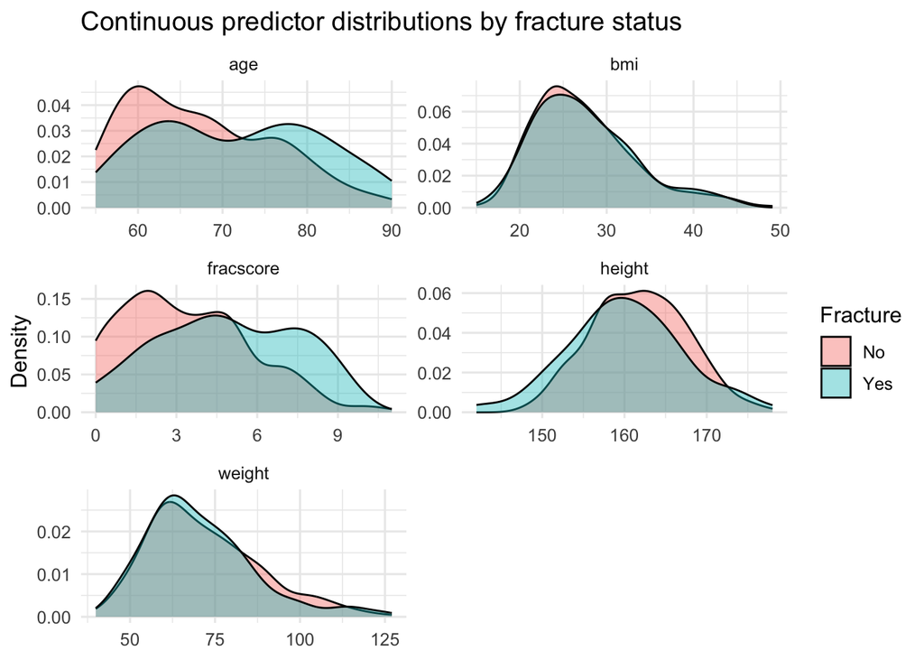

```r
continuous_variable = c(
  "age",
  "weight",
  "height",
  "bmi",
  "fracscore"
)

bone_train %>%
  pivot_longer(
    cols = all_of(continuous_variable),
    names_to = "predictor",
    values_to = "value"
  ) %>%
  ggplot(aes(x = value, fill = fracture)) +
  geom_density(alpha = 0.4, na.rm = TRUE) +
  facet_wrap(
    vars(predictor),
    scales = "free",
    ncol = 2
  ) +
  labs(
    title = "Continuous predictor distributions by fracture status",
    x = NULL,
    y = "Density",
    fill = "Fracture"
  ) +
  theme_minimal(base_size = 12)
```

Age: The fracture group is shifted toward older ages. Women who fractured appear more concentrated in the upper-age range, while women without fractures are more concentrated around the early-to-mid 60s. Fracture score: The fracture group is shifted toward higher scores. This suggests fracscore may be an important predictor of first-year fracture. BMI: The two curves overlap heavily, so BMI alone does not appear to strongly separate the fracture groups. Height: There is substantial overlap. Women with fractures may be slightly shorter on average, but the difference looks modest. Weight: The curves are also very similar, with little evidence of strong separation.

The density plots suggest that women who experienced a fracture tended to be older and have higher composite fracture-risk scores. BMI, height, and weight showed substantial overlap between fracture groups, indicating weaker unadjusted relationships with fracture status.

## boxplot of continous predcitors by status of fracture

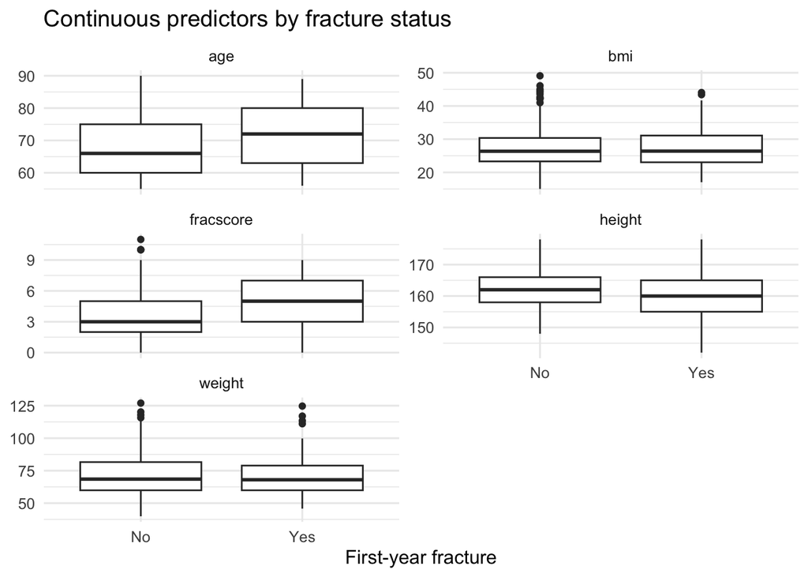

```r
bone_train %>%
  pivot_longer(
    cols = all_of(continuous_variable),
    names_to = "predictor",
    values_to = "value"
  ) |>
  ggplot(aes(x = fracture, y = value)) +
  geom_boxplot() +
  facet_wrap(
    vars(predictor),
    scales = "free_y",
    ncol = 2
  ) +
  labs(
    title = "Continuous predictors by fracture status",
    x = "First-year fracture",
    y = NULL
  ) +
  theme_minimal(base_size = 12)
```

```r
bone_train |>
  select(height, weight, bmi) |>
  pivot_longer(
    everything(),
    names_to = "variable",
    values_to = "value"
  ) |>
  group_by(variable) |>
  mutate(
    q1 = quantile(value, 0.25),
    q3 = quantile(value, 0.75),
    iqr = IQR(value),
    lower = q1 - 1.5 * iqr,
    upper = q3 + 1.5 * iqr
  ) |>
  filter(value < lower | value > upper) |>
  select(variable, value, lower, upper)
```

| variable | value | lower | upper |
| --- | --- | --- | --- |
| weight | 117.90000 | 27.50000 | 113.9000 |
| bmi | 42.27473 | 12.14694 | 41.7363 |
| height | 178.00000 | 145.00000 | 177.0000 |
| weight | 127.00000 | 27.50000 | 113.9000 |
| bmi | 44.99717 | 12.14694 | 41.7363 |
| bmi | 44.55552 | 12.14694 | 41.7363 |
| weight | 120.20000 | 27.50000 | 113.9000 |
| bmi | 44.15060 | 12.14694 | 41.7363 |
| bmi | 42.15439 | 12.14694 | 41.7363 |
| weight | 115.70000 | 27.50000 | 113.9000 |

[output cut: 12 more lines]

```r
bone_train |>
  mutate(row_id = row_number()) |>
  filter(
    bmi > 40 |
      weight > 110 |
      height < 145 |
      height > 180
  ) |>
  select(row_id, fracture, age, height, weight, bmi)
```

| row_id | fracture | age | height | weight | bmi |
| --- | --- | --- | --- | --- | --- |
| 6 | No | 56 | 167 | 117.9 | 42.27473 |
| 77 | No | 61 | 160 | 104.3 | 40.74219 |
| 84 | No | 70 | 168 | 110.7 | 39.22194 |
| 154 | No | 56 | 168 | 127.0 | 44.99717 |
| 156 | No | 64 | 153 | 104.3 | 44.55552 |
| 174 | No | 59 | 165 | 120.2 | 44.15060 |
| 190 | No | 74 | 163 | 112.0 | 42.15439 |
| 203 | No | 65 | 168 | 115.7 | 40.99348 |
| 225 | No | 60 | 156 | 106.1 | 43.59796 |
| 226 | No | 56 | 158 | 101.2 | 40.53838 |

[output cut: 11 more lines]

Age: The fracture group has a higher median age than the no-fracture group. This supports age as a potentially important predictor. Fracture score: The fracture group has a clearly higher median fracscore, with the entire distribution shifted upward. This appears to be the strongest continuous predictor visually. BMI: The medians and interquartile ranges are very similar. There are several high-BMI outliers, especially in the no-fracture group. Height: The fracture group appears slightly shorter on average, but the distributions overlap considerably. Weight: The two groups are very similar, with several high-weight outliers in both groups.

The boxplots show that women who fractured were generally older and had higher composite fracture-risk scores. BMI, height, and weight showed substantial overlap between outcome groups, suggesting weaker unadjusted associations with fracture status.

## catergorical predictors graph

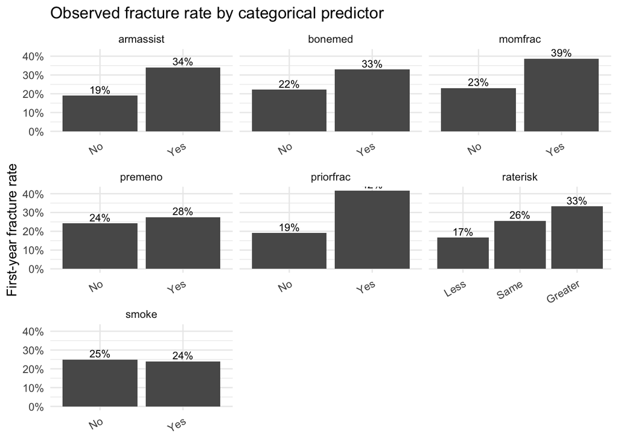

```r
categorical_variable = c(
  "priorfrac",
  "premeno",
  "momfrac",
  "armassist",
  "smoke",
  "raterisk",
  "bonemed"
)

bone_train %>%
  pivot_longer(
    cols = all_of(categorical_variable),
    names_to = "predictor",
    values_to = "category"
  ) |>
  group_by(predictor, category) |>
  summarise(
    n = n(),
    fracture_rate = mean(fracture == "Yes"),
    .groups = "drop"
  ) |>
  ggplot(
    aes(
      x = category,
      y = fracture_rate
    )
  ) +
  geom_col() +
  geom_text(
    aes(
      label = scales::percent(
        fracture_rate,
        accuracy = 1
      )
    ),
    vjust = -0.3,
    size = 3
  ) +
  facet_wrap(
    vars(predictor),
    scales = "free_x"
  ) +
  scale_y_continuous(
    labels = scales::percent,
    limits = c(0, NA)
  ) +
  labs(
    title = "Observed fracture rate by categorical predictor",
    x = NULL,
    y = "First-year fracture rate"
  ) +
  theme_minimal(base_size = 11) +
  theme(
    axis.text.x = element_text(
      angle = 30,
      hjust = 1
    )
  )
```

The categorical EDA suggests that prior fracture, use of arms to stand, maternal fracture history, self-rated fracture risk, and bone medication at enrollment are associated with higher observed fracture rates. Smoking and premenopausal fracture history show little separation between groups.

CAUTION: these are unadjusted rates. For example, the higher fracture rate among women taking bone medication does not mean the medication causes fractures. It may indicate confounding by indication, where women at greater baseline risk are more likely to be prescribed treatment.

## additive logistic regression model

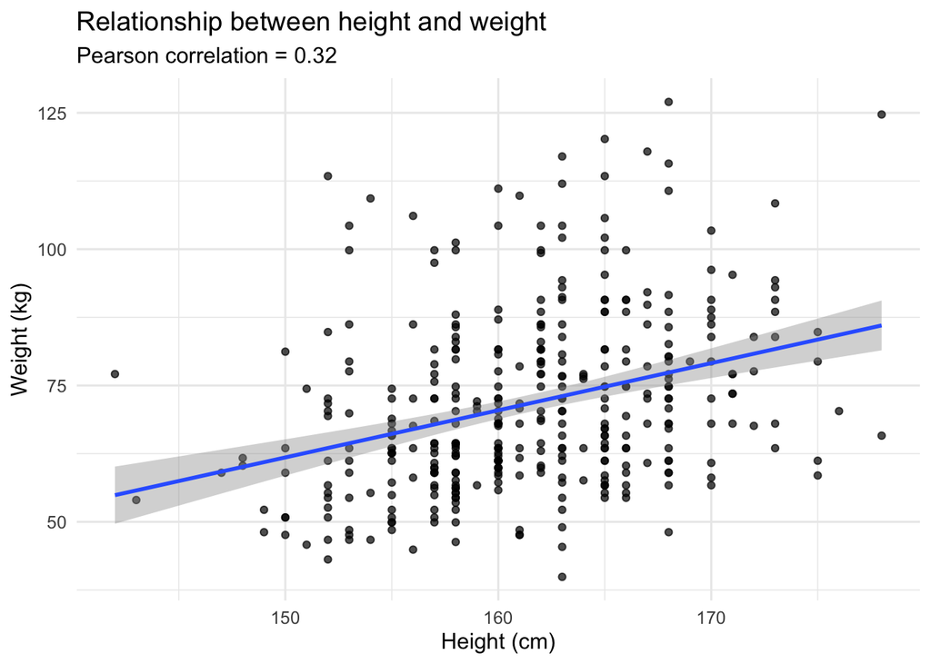

```r
#individual risk factor model where bmi is continuous
model_full_original = glm(
  fracture~ age + bmi + height + weight + priorfrac + momfrac + armassist + smoke + premeno + raterisk + bonemed,
  data = bone_train, family = binomial(link = "logit")
)

#checking for collinearity between height and weight
bone_train %>%
  ggplot(aes(x = height, y = weight)) +
  geom_point(alpha = 0.7) +
  geom_smooth(method = "lm", se = TRUE) +
  labs(
    title = "Relationship between height and weight",
    subtitle = paste(
      "Pearson correlation =",
      round(cor(bone_train$height, bone_train$weight), 2)
    ),
    x = "Height (cm)",
    y = "Weight (kg)"
  ) +
  theme_minimal(base_size = 12)
```

```r
#VIF
# library(car)
# vif_values = vif(model_height_weight)
# vif_values
```

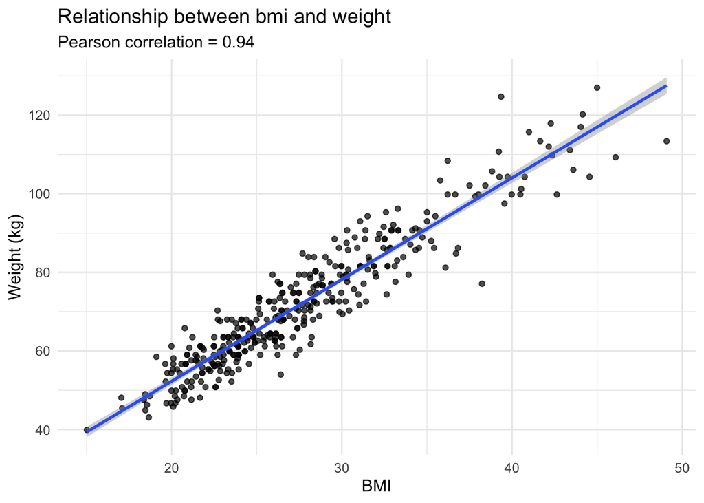

```r
#checking for collinearity between bmi and weight
bone_train %>%
  ggplot(aes(x = bmi, y = weight)) +
  geom_point(alpha = 0.7) +
  geom_smooth(method = "lm", se = TRUE) +
  labs(
    title = "Relationship between bmi and weight",
    subtitle = paste(
      "Pearson correlation =",
      round(cor(bone_train$bmi, bone_train$weight), 2)
    ),
    x = "BMI",
    y = "Weight (kg)"
  ) +
  theme_minimal(base_size = 12)
```

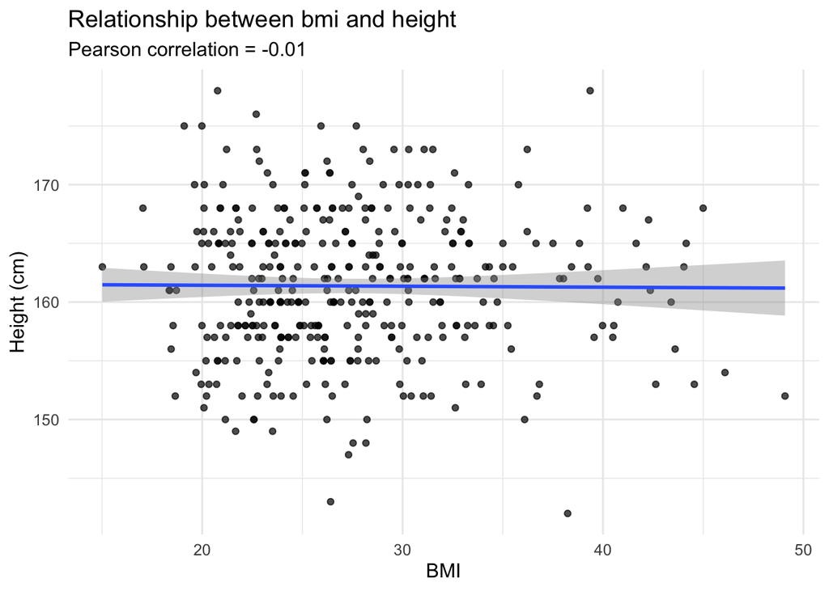

```r
#checking for collinearity between bmi and height
bone_train %>%
  ggplot(aes(x = bmi, y = height)) +
  geom_point(alpha = 0.7) +
  geom_smooth(method = "lm", se = TRUE) +
  labs(
    title = "Relationship between bmi and height",
    subtitle = paste(
      "Pearson correlation =",
      round(cor(bone_train$bmi, bone_train$height), 2)
    ),
    x = "BMI",
    y = "Height (cm)"
  ) +
  theme_minimal(base_size = 12)
```

```r
#VIF
library(car)
vif_values = vif(model_full_original)
vif_values
```

```
##                 GVIF Df GVIF^(1/(2*Df))
## age         1.485741  1        1.218910
## bmi       173.381323  1       13.167434
## height     21.681315  1        4.656320
## weight    191.256048  1       13.829535
## priorfrac   1.171380  1        1.082303
## momfrac     1.096505  1        1.047141
## armassist   1.380470  1        1.174934
## smoke       1.083186  1        1.040762
## premeno     1.142395  1        1.068829
## raterisk    1.261662  2        1.059829
## bonemed     1.247027  1        1.116704
```

In logistic regression, GVIF-adjusted values above 2–5 typically indicate meaningful multicollinearity. Values above 10 are considered severe. Here, both BMI and weight exceed 13, and height exceeds 4.5, clearly signaling problematic collinearity.

```r
#question with bmi- to include in additive model or not?
#make bmi categorical
bone_train = bone_train %>%
  mutate(
    bmi_categorical = cut(
      bmi,
      breaks = c(-Inf, 18.5, 25, 30, Inf),
      labels = c(
        "Underweight",
        "Normal",
        "Overweight",
        "Obesity"
      ),
      right = FALSE
    ),
    bmi_categorical = relevel(bmi_categorical, ref = "Normal")
  )

#individual risk factor model where bmi is continuous
model_cont_bmi = glm(
  fracture~ age + bmi + priorfrac + momfrac + armassist + smoke + premeno + raterisk + bonemed,
  data = bone_train, family = binomial(link = "logit")
)

#bmi categorical model
model_cat_bmi = glm(
  fracture ~ age + bmi_categorical + priorfrac + momfrac + armassist + smoke + premeno + raterisk + bonemed, data = bone_train, family = binomial(link = "logit") )

#model with Cat BMI and Weight + Height
model_cat_bmi_height_weight = glm(
  fracture ~ age + bmi_categorical + height + weight + priorfrac + momfrac + armassist + smoke + premeno + raterisk + bonemed, data = bone_train, family = binomial(link = "logit") )

#model with Cat BMI and Weight
model_cat_bmi_weight = glm(
  fracture ~ age + bmi_categorical + weight + priorfrac + momfrac + armassist + smoke + premeno + raterisk + bonemed, data = bone_train, family = binomial(link = "logit") )

#model with Cat BMI and Height
model_cat_bmi_height = glm(
  fracture ~ age + bmi_categorical + height + priorfrac + momfrac + armassist + smoke + premeno + raterisk + bonemed, data = bone_train, family = binomial(link = "logit") )

#model with height and weight
model_height_weight = glm(
  fracture~ age + height + weight + priorfrac + momfrac + armassist + smoke + premeno + raterisk + bonemed,
  data = bone_train, family = binomial(link = "logit")
)

#model with height only
model_height_only = glm(
  fracture~ age + height + priorfrac + momfrac + armassist + smoke + premeno + raterisk + bonemed,
  data = bone_train, family = binomial(link = "logit")
)

#model with weight only
model_weight_only = glm(
  fracture~ age + weight + priorfrac + momfrac + armassist + smoke + premeno + raterisk + bonemed,
  data = bone_train, family = binomial(link = "logit")
)

#Comparing using AIC Cont BMI vs Categorical BMI
AIC(
  model_cont_bmi,
  model_cat_bmi
)
```

|  | df | AIC |
| --- | --- | --- |
| model_cont_bmi | 11 | 401.1629 |
| model_cat_bmi | 13 | 403.7469 |

```r
#Comparing using AIC the Cat_BMI with Height+Weight, Height, and Weight
AIC(
  model_cat_bmi,
  model_cat_bmi_height_weight,
  model_cat_bmi_weight,
  model_cat_bmi_height
)
```

|  | df | AIC |
| --- | --- | --- |
| model_cat_bmi | 13 | 403.7469 |
| model_cat_bmi_height_weight | 15 | 403.1191 |
| model_cat_bmi_weight | 14 | 402.5967 |
| model_cat_bmi_height | 14 | 401.7003 |

```r
#Comparing Winning Model from above ^ with no BMI with Height+Weight, Height, and Weight
AIC(
  model_cat_bmi_height,
  model_height_weight,
  model_height_only,
  model_weight_only
)
```

|  | df | AIC |
| --- | --- | --- |
| model_cat_bmi_height | 14 | 401.7003 |
| model_height_weight | 12 | 399.1812 |
| model_height_only | 11 | 397.6989 |
| model_weight_only | 11 | 402.1198 |

Comparison 1 (Continuous BMI vs Categorical BMI): Our EDA showed that BMI’s relationship with fracture risk was weakly linear, and categorizing BMI removes the linearity assumption while aligning with clinically meaningful thresholds (underweight, normal, overweight, obesity). These categories are widely used in fracture‑risk guidelines and improve interpretability of odds ratios. Because Objective 1 emphasizes interpretability rather than predictive optimization, the categorical BMI model is preferable even if its AIC is marginally higher.

Comparison 2 (Categorical BMI vs Including Height+Weight, Weight, and Height): With additional nuance from other important variables such as height and weight which are basic measures that are easily taken from patient before any examination, which are heavily used as risk factors we may choose to include these additional nuances now that they are not linearly related with another predictor being the BMI which is now categorical. Model with Categorical BMI and Height included had the lower AIC to be the best interetable model and best performing model.

```r
final_additive_model = glm(
  fracture ~ age + height + priorfrac + momfrac + armassist + smoke + raterisk + bonemed,
  data = bone_train,
  family = binomial(link = "logit")
)

summary(final_additive_model)
```

```
##
## Call:
## glm(formula = fracture ~ age + height + priorfrac + momfrac +
##     armassist + smoke + raterisk + bonemed, family = binomial(link = "logit"),
##     data = bone_train)
##
## Coefficients:
##                 Estimate Std. Error z value Pr(>|z|)
## (Intercept)      3.45941    3.78688   0.914  0.36097
## age              0.02838    0.01545   1.838  0.06613 .
## height          -0.04640    0.02171  -2.138  0.03253 *
## priorfracYes     0.78239    0.28770   2.719  0.00654 **
## momfracYes       0.77392    0.37366   2.071  0.03834 *
## armassistYes     0.54320    0.27673   1.963  0.04965 *
## smokeYes        -0.14010    0.52246  -0.268  0.78858
## rateriskSame     0.36774    0.33332   1.103  0.26990
## rateriskGreater  0.60358    0.35285   1.711  0.08716 .
## bonemedYes       0.08169    0.29930   0.273  0.78490
## ---
## Signif. codes:  0 '***' 0.001 '**' 0.01 '*' 0.05 '.' 0.1 ' ' 1
##
## (Dispersion parameter for binomial family taken to be 1)
##
##     Null deviance: 419.52  on 373  degrees of freedom
## Residual deviance: 375.98  on 364  degrees of freedom
## AIC: 395.98
##
## Number of Fisher Scoring iterations: 4
```

```r
AIC(final_additive_model)
```

```
## [1] 395.9844
```

Checking for influential observation

```r
library(broom)

model_diagnostics =  augment(final_additive_model) %>%
  mutate(
    observation = row_number(),
    cooks_cutoff = 4 / nrow(bone_train)
  )

model_diagnostics %>%
  arrange(desc(.cooksd)) %>%
  select(
    observation,
    fracture,
    .fitted,
    .std.resid,
    .hat,
    .cooksd
  ) |>
  slice_head(n = 10)
```

| observation | fracture | .fitted | .std.resid | .hat | .cooksd |
| --- | --- | --- | --- | --- | --- |
| 295 | Yes | -0.8036182 | 1.618472 | 0.10393563 | 0.02891299 |
| 284 | Yes | -0.8899149 | 1.645627 | 0.08866037 | 0.02599286 |
| 362 | Yes | -1.5557754 | 1.913149 | 0.04525829 | 0.02352833 |
| 300 | Yes | -1.1915814 | 1.759608 | 0.05896979 | 0.02192399 |
| 345 | Yes | -1.2153760 | 1.759496 | 0.04702620 | 0.01745858 |
| 367 | Yes | -0.7193211 | 1.551408 | 0.07253902 | 0.01731321 |
| 248 | No | 1.0918617 | -1.704621 | 0.04930307 | 0.01625471 |
| 307 | Yes | -1.4879507 | 1.870714 | 0.03326873 | 0.01576280 |
| 294 | Yes | -1.8464754 | 2.020578 | 0.02369836 | 0.01575667 |
| 67 | No | 1.2889474 | -1.786608 | 0.03988139 | 0.01570013 |

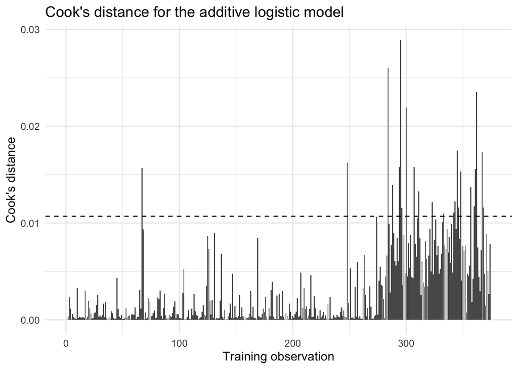

```r
#cooks d plot
model_diagnostics %>%
  ggplot(aes(x = observation, y = .cooksd)) +
  geom_col() +
  geom_hline(
    yintercept = 4 / nrow(bone_train),
    linetype = 2
  ) +
  labs(
    title = "Cook's distance for the additive logistic model",
    x = "Training observation",
    y = "Cook's distance"
  ) +
  theme_minimal(base_size = 12)
```

```r
#checking for observations with large residuals
model_diagnostics %>%
  filter(abs(.std.resid) > 2) %>%
  arrange(desc(abs(.std.resid))) %>%
  select(
    observation,
    fracture,
    .fitted,
    .std.resid,
    .hat,
    .cooksd
  )
```

| observation | fracture | .fitted | .std.resid | .hat | .cooksd |
| --- | --- | --- | --- | --- | --- |
| 292 | Yes | -2.445103 | 2.256856 | 0.007238778 | 0.008469745 |
| 374 | Yes | -2.409063 | 2.241704 | 0.006952971 | 0.007842841 |
| 344 | Yes | -2.258026 | 2.181892 | 0.009602425 | 0.009362896 |
| 333 | Yes | -2.143710 | 2.136928 | 0.012560494 | 0.010989734 |
| 327 | Yes | -2.145952 | 2.132611 | 0.007676341 | 0.006665344 |
| 323 | Yes | -1.953254 | 2.059737 | 0.016682708 | 0.012166532 |
| 337 | Yes | -1.957629 | 2.054287 | 0.009641999 | 0.006962576 |
| 366 | Yes | -1.951219 | 2.051905 | 0.010008626 | 0.007186464 |
| 294 | Yes | -1.846475 | 2.020578 | 0.023698360 | 0.015756667 |
| 318 | Yes | -1.866067 | 2.014636 | 0.009581766 | 0.006312932 |

diagnostic info: model has some observations worth investigating, but there is no evidence of an extreme influence problem.

cook’s d: Several observations were flagged as potentially influential using the 4/n screening rule, but none had an exceptionally large Cook’s distance. These observations were retained and examined through sensitivity analysis.

The increasing concentration of larger bars near the end of the graph is likely because the training rows are ordered or grouped by fracture status. It does not necessarily imply that later observations are inherently problematic.

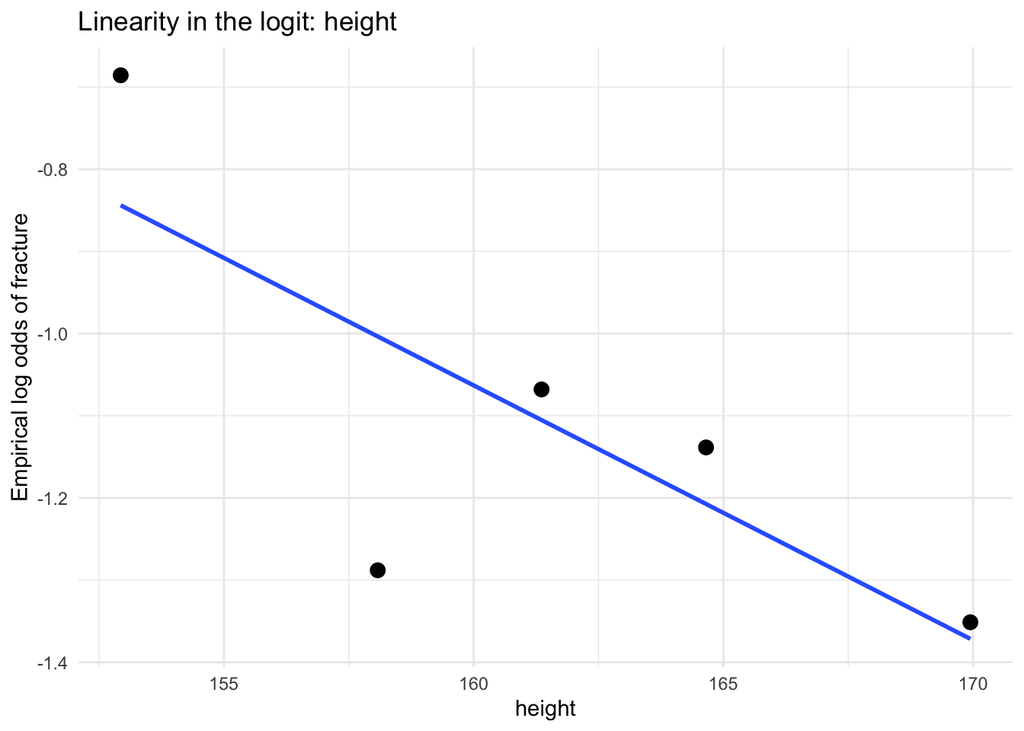

```r
check_logit_linearity = function(data, variable, groups = 5) {
  data %>%
    mutate(group = ntile(.data[[variable]], groups)) %>%
    group_by(group) %>%
    summarise(
      predictor_mean = mean(.data[[variable]], na.rm = TRUE),
      fracture_rate = mean(fracture == "Yes"),
      n = n(),
      .groups = "drop"
    ) %>%
    mutate(
      empirical_logit = log(
        (fracture_rate + 0.005) /
          (1 - fracture_rate + 0.005)
      )
    ) %>%
    ggplot(aes(x = predictor_mean, y = empirical_logit)) +
    geom_point(size = 3) +
    geom_smooth(method = "lm", se = FALSE) +
    labs(
      title = paste("Linearity in the logit:", variable),
      x = variable,
      y = "Empirical log odds of fracture"
    ) +
    theme_minimal()
}


check_logit_linearity(bone_train, "height")
```

An empirical-logit plot groups the continuous predictor into bins, calculates the observed fracture proportion in each bin, and transforms that proportion to log odds:

## fit and summarixe the final model

```r
final_additive_model = glm(
  fracture ~ age + height + priorfrac + momfrac + armassist + smoke + raterisk + bonemed,
  data = bone_train,
  family = binomial(link = "logit")
)

summary(final_additive_model)
```

```
##
## Call:
## glm(formula = fracture ~ age + height + priorfrac + momfrac +
##     armassist + smoke + raterisk + bonemed, family = binomial(link = "logit"),
##     data = bone_train)
##
## Coefficients:
##                 Estimate Std. Error z value Pr(>|z|)
## (Intercept)      3.45941    3.78688   0.914  0.36097
## age              0.02838    0.01545   1.838  0.06613 .
## height          -0.04640    0.02171  -2.138  0.03253 *
## priorfracYes     0.78239    0.28770   2.719  0.00654 **
## momfracYes       0.77392    0.37366   2.071  0.03834 *
## armassistYes     0.54320    0.27673   1.963  0.04965 *
## smokeYes        -0.14010    0.52246  -0.268  0.78858
## rateriskSame     0.36774    0.33332   1.103  0.26990
## rateriskGreater  0.60358    0.35285   1.711  0.08716 .
## bonemedYes       0.08169    0.29930   0.273  0.78490
## ---
## Signif. codes:  0 '***' 0.001 '**' 0.01 '*' 0.05 '.' 0.1 ' ' 1
##
## (Dispersion parameter for binomial family taken to be 1)
##
##     Null deviance: 419.52  on 373  degrees of freedom
## Residual deviance: 375.98  on 364  degrees of freedom
## AIC: 395.98
##
## Number of Fisher Scoring iterations: 4
```

```r
AIC(final_additive_model)
```

```
## [1] 395.9844
```

```r
# odds ratio and 95% CI
final_additive_table = tidy(
  final_additive_model,
  exponentiate = TRUE,
  conf.int = TRUE
) %>%
  transmute(
    term,
    odds_ratio = round(estimate, 3),
    CI_low = round(conf.low, 3),
    CI_high = round(conf.high, 3),
    p_value = round(p.value, 3)
  )

final_additive_table
```

| term | odds_ratio | CI_low | CI_high | p_value |
| --- | --- | --- | --- | --- |
| (Intercept) | 31.798 | 0.019 | 56312.306 | 0.361 |
| age | 1.029 | 0.998 | 1.061 | 0.066 |
| height | 0.955 | 0.914 | 0.996 | 0.033 |
| priorfracYes | 2.187 | 1.241 | 3.843 | 0.007 |
| momfracYes | 2.168 | 1.030 | 4.492 | 0.038 |
| armassistYes | 1.722 | 1.000 | 2.965 | 0.050 |
| smokeYes | 0.869 | 0.289 | 2.307 | 0.789 |
| rateriskSame | 1.444 | 0.755 | 2.803 | 0.270 |
| rateriskGreater | 1.829 | 0.919 | 3.685 | 0.087 |
| bonemedYes | 1.085 | 0.598 | 1.939 | 0.785 |

```r
# interpretations
# 10-year increase in age
exp(10 * coef(final_additive_model)["age"])
```

```
##      age
## 1.328218
```

```r
exp(10 * confint(final_additive_model, parm = "age"))
```

```
##     2.5 %    97.5 %
## 0.9810475 1.8006873
```

```r
# 10-cm increase in height
exp(10 * coef(final_additive_model)["height"])
```

```
##    height
## 0.6287387
```

```r
exp(10 * confint(final_additive_model, parm = "height"))
```

```
##     2.5 %    97.5 %
## 0.4083352 0.9587588
```

```r
# 10-kg increase in weight
# exp(10 * coef(final_additive_model)["weight"])
# exp(10 * confint(final_additive_model, parm = "weight"))
```

## objective 2

models needed: 1. complex logisitc model 2. LDA 3. QDA 4. Non parametric model

comparison on validation set using –> sensitivity, specificity, prevalence, PPV, NPV, and AUROC Sensitivity asks: “Of the women who fractured, how many did we catch?” Specificity asks: “Of the women who did not fracture, how many did we correctly leave as low risk?” Prevalence asks: “How common was fracture in this sample?”

## keeping the same split from objective 1 & creating 5 CV

```r
library(tidymodels)
library(tidyverse)

set.seed(1234)

bone.folds = vfold_cv(
  bone_train,
  v = 5,
  strata = fracture  #using fracture to keep the same fracture proportion in each fold
)

bone.folds
```

| splits | id |
| --- | --- |
|  | Fold1 |
|  | Fold2 |
|  | Fold3 |
|  | Fold4 |
|  | Fold5 |

## establish/calculate the basline validation perfomance of objective 1 logisitc model

```r
baseline_prediction = bone_test %>%
  mutate(
    .pred_Yes = predict(
      final_additive_model,
      newdata = bone_test,
      type = "response"
    )
  )

#checking
baseline_prediction %>%
  select(fracture, .pred_Yes) %>%
  head()
```

|  | fracture | .pred_Yes |
| --- | --- | --- |
| 1 | No | 0.1486947 |
| 2 | No | 0.6837967 |
| 3 | No | 0.1831970 |
| 4 | No | 0.4797367 |
| 5 | No | 0.4530226 |
| 6 | No | 0.2488298 |

.pred_Yes is the estimated probability that the woman fractures - but there is 32/126 = 25.4% of fracture prevalence in the validations set

## calculate AUROC

```r
library(yardstick)

roc_auc(
  baseline_prediction,
  truth = fracture,
  .pred_Yes,
  event_level = "second" # we use this because the factor levels are - No and Yes but here we care for Yes events
)
```

| .metric | .estimator | .estimate |
| --- | --- | --- |
| roc_auc | binary | 0.723238 |

AUROC–> if you randomly select one woman who fractured and one who did not, the model will assign the fracture case a higher predicted risk about 72.3% of the time

## calculate the threshold-baseline at 0.50 as standard first

```r
baseline_prediction = baseline_prediction %>%
  mutate(
    .pred_class = factor(
      if_else(.pred_Yes >= 0.50, "Yes", "No"),
      levels = c("No", "Yes")
    )
  )

#CM
conf_mat(
  baseline_prediction,
  truth = fracture,
  estimate = .pred_class
)
```

```
##           Truth
## Prediction No Yes
##        No  88  25
##        Yes  6   7
```

```r
#calculating the required metrics
sens(
  baseline_prediction,
  truth = fracture,
  estimate = .pred_class,
  event_level = "second"
)
```

| .metric | .estimator | .estimate |
| --- | --- | --- |
| sens | binary | 0.21875 |

```r
yardstick::spec(
  baseline_prediction,
  truth = fracture,
  estimate = .pred_class,
  event_level = "second"
)
```

| .metric | .estimator | .estimate |
| --- | --- | --- |
| spec | binary | 0.9361702 |

```r
ppv(
  baseline_prediction,
  truth = fracture,
  estimate = .pred_class,
  event_level = "second"
)
```

| .metric | .estimator | .estimate |
| --- | --- | --- |
| ppv | binary | 0.5384615 |

```r
npv(
  baseline_prediction,
  truth = fracture,
  estimate = .pred_class,
  event_level = "second"
)
```

| .metric | .estimator | .estimate |
| --- | --- | --- |
| npv | binary | 0.7787611 |

```r
#prevalence
mean(baseline_prediction$fracture =="Yes")
```

```
## [1] 0.2539683
```

## combining them

```r
baseline_metrics = tibble(
  Model = "Additive Logistic",
  Threshold = 0.50,
  Sensitivity = sens_vec(
    baseline_prediction$fracture,
    baseline_prediction$.pred_class,
    event_level = "second"
  ),
  Specificity = spec_vec(
    baseline_prediction$fracture,
    baseline_prediction$.pred_class,
    event_level = "second"
  ),
  PPV = ppv_vec(
    baseline_prediction$fracture,
    baseline_prediction$.pred_class,
    event_level = "second"
  ),
  NPV = npv_vec(
    baseline_prediction$fracture,
    baseline_prediction$.pred_class,
    event_level = "second"
  ),
  Prevalence = mean(baseline_prediction$fracture == "Yes"),
  AUROC = roc_auc_vec(
    baseline_prediction$fracture,
    baseline_prediction$.pred_Yes,
    event_level = "second"
  )
)

baseline_metrics
```

| Model | Threshold | Sensitivity | Specificity | PPV | NPV | Prevalence | AUROC |
| --- | --- | --- | --- | --- | --- | --- | --- |
| Additive Logistic | 0.5 | 0.21875 | 0.9361702 | 0.5384615 | 0.7787611 | 0.2539683 | 0.723238 |

It correctly identifies most women who will not fracture, but it misses many women who actually do fracture.

A sensitivity of 0.219 means the model only identifies about 21.9% of the true fracture cases at the 0.50 threshold.

Because fracture detection is probably the more important goal here, this is a strong reason to revisit the threshold later. A lower threshold should increase sensitivity, though specificity will decrease.

## complex logistic regression model

```r
complex_model = glm(
    fracture ~
    age +
    I(age^2) +  #allows fracture risk to accelerate at older ages
    height +
    priorfrac +
    momfrac +
    armassist +
    smoke +
    raterisk +
    bonemed +
    age:priorfrac + #test whether the effect of prior fracture differs with age
    priorfrac:raterisk, #test whether perceived risk carries different information among woman with vs without a previous fracture
  data = bone_train,
  family = binomial(link = "logit")
)

summary(complex_model)
```

```
##
## Call:
## glm(formula = fracture ~ age + I(age^2) + height + priorfrac +
##     momfrac + armassist + smoke + raterisk + bonemed + age:priorfrac +
##     priorfrac:raterisk, family = binomial(link = "logit"), data = bone_train)
##
## Coefficients:
##                               Estimate Std. Error z value Pr(>|z|)
## (Intercept)                   9.255636   8.495338   1.089   0.2759
## age                          -0.191855   0.227946  -0.842   0.4000
## I(age^2)                      0.001687   0.001611   1.047   0.2949
## height                       -0.039147   0.022078  -1.773   0.0762 .
## priorfracYes                  4.948885   2.319313   2.134   0.0329 *
## momfracYes                    0.775788   0.376278   2.062   0.0392 *
## armassistYes                  0.499294   0.281335   1.775   0.0759 .
## smokeYes                     -0.257556   0.539010  -0.478   0.6328
## rateriskSame                  0.523377   0.400983   1.305   0.1918
## rateriskGreater               0.623231   0.449497   1.387   0.1656
## bonemedYes                    0.159377   0.302374   0.527   0.5981
## age:priorfracYes             -0.055162   0.031014  -1.779   0.0753 .
## priorfracYes:rateriskSame    -0.472833   0.704740  -0.671   0.5023
## priorfracYes:rateriskGreater -0.136653   0.699449  -0.195   0.8451
## ---
## Signif. codes:  0 '***' 0.001 '**' 0.01 '*' 0.05 '.' 0.1 ' ' 1
##
## (Dispersion parameter for binomial family taken to be 1)
##
##     Null deviance: 419.52  on 373  degrees of freedom
## Residual deviance: 371.93  on 360  degrees of freedom
## AIC: 399.93
##
## Number of Fisher Scoring iterations: 4
```

```r
#compare to additive model
AIC(
  final_additive_model,
  complex_model
)
```

|  | df | AIC |
| --- | --- | --- |
| final_additive_model | 10 | 395.9844 |
| complex_model | 14 | 399.9329 |

```r
#compare nested model
anova(
  final_additive_model,
  complex_model,
  test = "Chisq"
)
```

|  | Resid. Df | Resid. Dev | Df | Deviance | Pr(>Chi) |
| --- | --- | --- | --- | --- | --- |
| 1 | 364 | 375.9844 | NA | NA | NA |
| 2 | 360 | 371.9329 | 4 | 4.051522 | 0.399078 |

We tested a more complex logistic regression model containing a quadratic age term and interactions between age and prior fracture, and between prior fracture and self-rated risk. The complex model had a higher AIC than the additive model (399.93 vs. 395.98), and the likelihood-ratio test was not significant (p=0.399).

Therefore, the added complexity was not supported by the training data, but the model was retained for predictive comparison as required

## generate validation predictions for complex logistic model

```r
complex_prediction = bone_test %>%
  mutate(
    .pred_Yes = predict(
      complex_model,
      newdata = bone_test,
      type = "response"
    ),
    .pred_class = factor(
      if_else(.pred_Yes >= 0.50, "Yes", "No"),
      levels = c("No", "Yes")
    )
  )

# calculate the validation metrics
complex_metrics = tibble(
  Model = "Complex Logistic",
  Threshold = 0.50,

  Sensitivity = yardstick::sens_vec(
    complex_prediction$fracture,
    complex_prediction$.pred_class,
    event_level = "second"
  ),

  Specificity = yardstick::spec_vec(
    complex_prediction$fracture,
    complex_prediction$.pred_class,
    event_level = "second"
  ),

  PPV = yardstick::ppv_vec(
    complex_prediction$fracture,
    complex_prediction$.pred_class,
    event_level = "second"
  ),

  NPV = yardstick::npv_vec(
    complex_prediction$fracture,
    complex_prediction$.pred_class,
    event_level = "second"
  ),

  Prevalence = mean(
    complex_prediction$fracture == "Yes"
  ),

  AUROC = yardstick::roc_auc_vec(
    complex_prediction$fracture,
    complex_prediction$.pred_Yes,
    event_level = "second"
  )
)

complex_metrics
```

| Model | Threshold | Sensitivity | Specificity | PPV | NPV | Prevalence | AUROC |
| --- | --- | --- | --- | --- | --- | --- | --- |
| Complex Logistic | 0.5 | 0.1875 | 0.9574468 | 0.6 | 0.7758621 | 0.2539683 | 0.7175864 |

## comparing the 2 logistic models

```r
bind_rows(
  baseline_metrics,
  complex_metrics
)
```

| Model | Threshold | Sensitivity | Specificity | PPV | NPV | Prevalence | AUROC |
| --- | --- | --- | --- | --- | --- | --- | --- |
| Additive Logistic | 0.5 | 0.21875 | 0.9361702 | 0.5384615 | 0.7787611 | 0.2539683 | 0.7232380 |
| Complex Logistic | 0.5 | 0.18750 | 0.9574468 | 0.6000000 | 0.7758621 | 0.2539683 | 0.7175864 |

So the complex model gained a little specificity and PPV, but it lost sensitivity and AUROC. Since your main concern is likely identifying women who will fracture, that trade off is not especially attractive. Also, the training AIC and likelihood-ratio test already favored the simpler additive mode

The complex logistic model did not improve predictive discrimination over the additive model. At a 0.50 threshold, it produced slightly higher specificity and PPV, but lower sensitivity and AUROC. Thus, the added interactions and quadratic age term did not appear beneficial.

## complex model with categorical bmi

## creating new split with categorical bmi

```r
#training set including bmi categorical
bone_train = bone_train %>%
  mutate(
    bmi_categorical = cut(
      bmi,
      breaks = c(-Inf, 18.5, 25, 30, Inf),
      labels = c(
        "Underweight",
        "Normal",
        "Overweight",
        "Obesity"
      ),
      right = FALSE
    ),
    bmi_categorical = relevel(bmi_categorical, ref = "Normal")

  )

#validation set including bmi categorical
bone_test = bone_test %>%
  mutate(
    bmi_categorical = cut(
      bmi,
      breaks = c(-Inf, 18.5, 25, 30, Inf),
      labels = c(
        "Underweight",
        "Normal",
        "Overweight",
        "Obesity"
      ),
      right = FALSE
    ),
    bmi_categorical = relevel(bmi_categorical, ref = "Normal")

  )


#fiting the model
model_cat_bmi = glm(
  fracture ~ age + bmi_categorical + priorfrac + momfrac + armassist + smoke + premeno + raterisk + bonemed, data = bone_train, family = binomial(link = "logit") )

summary(model_cat_bmi)
```

```
##
## Call:
## glm(formula = fracture ~ age + bmi_categorical + priorfrac +
##     momfrac + armassist + smoke + premeno + raterisk + bonemed,
##     family = binomial(link = "logit"), data = bone_train)
##
## Coefficients:
##                            Estimate Std. Error z value Pr(>|z|)
## (Intercept)                -5.19994    1.21620  -4.276 1.91e-05 ***
## age                         0.04321    0.01649   2.620   0.0088 **
## bmi_categoricalUnderweight -0.76081    0.90948  -0.837   0.4029
## bmi_categoricalOverweight   0.09774    0.31986   0.306   0.7599
## bmi_categoricalObesity      0.41506    0.36159   1.148   0.2510
## priorfracYes                0.75571    0.29140   2.593   0.0095 **
## momfracYes                  0.74255    0.36919   2.011   0.0443 *
## armassistYes                0.31978    0.28633   1.117   0.2641
## smokeYes                   -0.09678    0.52411  -0.185   0.8535
## premenoYes                  0.21792    0.33132   0.658   0.5107
## rateriskSame                0.39293    0.33347   1.178   0.2387
## rateriskGreater             0.68573    0.35920   1.909   0.0563 .
## bonemedYes                  0.26535    0.31191   0.851   0.3949
## ---
## Signif. codes:  0 '***' 0.001 '**' 0.01 '*' 0.05 '.' 0.1 ' ' 1
##
## (Dispersion parameter for binomial family taken to be 1)
##
##     Null deviance: 419.52  on 373  degrees of freedom
## Residual deviance: 377.75  on 361  degrees of freedom
## AIC: 403.75
##
## Number of Fisher Scoring iterations: 4
```

```r
AIC(model_cat_bmi)
```

```
## [1] 403.7469
```

## adding interactions to complex cat bmi model

```r
complex_cat_bmi_model = glm(
    fracture ~
    bmi_categorical +
    age +
    I(age^2) +  #allows fracture risk to accelerate at older ages
    height +
    priorfrac +
    momfrac +
    armassist +
    smoke +
    raterisk +
    bonemed +
    age:priorfrac + #test whether the effect of prior fracture differs with age
    priorfrac:raterisk, #test whether perceived risk carries different information among woman with vs without a previous fracture
  data = bone_train,
  family = binomial(link = "logit")
)

summary(complex_cat_bmi_model)
```

```
##
## Call:
## glm(formula = fracture ~ bmi_categorical + age + I(age^2) + height +
##     priorfrac + momfrac + armassist + smoke + raterisk + bonemed +
##     age:priorfrac + priorfrac:raterisk, family = binomial(link = "logit"),
##     data = bone_train)
##
## Coefficients:
##                               Estimate Std. Error z value Pr(>|z|)
## (Intercept)                   9.691763   8.545704   1.134   0.2567
## bmi_categoricalUnderweight   -0.614881   0.953895  -0.645   0.5192
## bmi_categoricalOverweight     0.079997   0.324513   0.247   0.8053
## bmi_categoricalObesity        0.463691   0.366044   1.267   0.2052
## age                          -0.225755   0.230989  -0.977   0.3284
## I(age^2)                      0.001981   0.001635   1.211   0.2258
## height                       -0.037222   0.022140  -1.681   0.0927 .
## priorfracYes                  4.999598   2.343233   2.134   0.0329 *
## momfracYes                    0.852985   0.381726   2.235   0.0254 *
## armassistYes                  0.384139   0.294961   1.302   0.1928
## smokeYes                     -0.187582   0.540563  -0.347   0.7286
## rateriskSame                  0.522440   0.402868   1.297   0.1947
## rateriskGreater               0.702712   0.455950   1.541   0.1233
## bonemedYes                    0.278659   0.315949   0.882   0.3778
## age:priorfracYes             -0.055230   0.031455  -1.756   0.0791 .
## priorfracYes:rateriskSame    -0.548802   0.712000  -0.771   0.4408
## priorfracYes:rateriskGreater -0.223868   0.706421  -0.317   0.7513
## ---
## Signif. codes:  0 '***' 0.001 '**' 0.01 '*' 0.05 '.' 0.1 ' ' 1
##
## (Dispersion parameter for binomial family taken to be 1)
##
##     Null deviance: 419.52  on 373  degrees of freedom
## Residual deviance: 369.57  on 357  degrees of freedom
## AIC: 403.57
##
## Number of Fisher Scoring iterations: 4
```

```r
#compare to additive model
AIC(
  final_additive_model,
  complex_model,
  complex_cat_bmi_model
)
```

|  | df | AIC |
| --- | --- | --- |
| final_additive_model | 10 | 395.9844 |
| complex_model | 14 | 399.9329 |
| complex_cat_bmi_model | 17 | 403.5712 |

```r
#compare nested model
anova(
  final_additive_model,
  complex_model,
  complex_cat_bmi_model,
  test = "Chisq"
)
```

|  | Resid. Df | Resid. Dev | Df | Deviance | Pr(>Chi) |
| --- | --- | --- | --- | --- | --- |
| 1 | 364 | 375.9844 | NA | NA | NA |
| 2 | 360 | 371.9329 | 4 | 4.051522 | 0.399078 |
| 3 | 357 | 369.5712 | 3 | 2.361668 | 0.500810 |

# generate predictions for complex cat bmi model

```r
complex_cat_bmi_prediction = bone_test %>%
  mutate(
    .pred_Yes = predict(
      complex_cat_bmi_model,
      newdata = bone_test,
      type = "response"
    ),
    .pred_class = factor(
      if_else(.pred_Yes >= 0.50, "Yes", "No"),
      levels = c("No", "Yes")
    )
  )

# calculate the validation metrics
complex_cat_bmi_metrics = tibble(
  Model = "Complex Categorical BMI Logistic",
  Threshold = 0.50,

  Sensitivity = yardstick::sens_vec(
    complex_cat_bmi_prediction$fracture,
    complex_cat_bmi_prediction$.pred_class,
    event_level = "second"
  ),

  Specificity = yardstick::spec_vec(
    complex_cat_bmi_prediction$fracture,
    complex_cat_bmi_prediction$.pred_class,
    event_level = "second"
  ),

  PPV = yardstick::ppv_vec(
    complex_cat_bmi_prediction$fracture,
    complex_cat_bmi_prediction$.pred_class,
    event_level = "second"
  ),

  NPV = yardstick::npv_vec(
    complex_cat_bmi_prediction$fracture,
    complex_cat_bmi_prediction$.pred_class,
    event_level = "second"
  ),

  Prevalence = mean(
    complex_cat_bmi_prediction$fracture == "Yes"
  ),

  AUROC = yardstick::roc_auc_vec(
    complex_cat_bmi_prediction$fracture,
    complex_cat_bmi_prediction$.pred_Yes,
    event_level = "second"
  )
)

complex_cat_bmi_metrics
```

| Model | Threshold | Sensitivity | Specificity | PPV | NPV | Prevalence | AUROC |
| --- | --- | --- | --- | --- | --- | --- | --- |
| Complex Categorical BMI Logistic | 0.5 | 0.1875 | 0.9468085 | 0.5454545 | 0.773913 | 0.2539683 | 0.7177527 |

## loess plot to compare the 2 complex models

```r
# get the predicting probabilities on the training data
complex_model
```

```
##
## Call:  glm(formula = fracture ~ age + I(age^2) + height + priorfrac +
##     momfrac + armassist + smoke + raterisk + bonemed + age:priorfrac +
##     priorfrac:raterisk, family = binomial(link = "logit"), data = bone_train)
##
## Coefficients:
##                  (Intercept)                           age
##                     9.255636                     -0.191855
##                     I(age^2)                        height
##                     0.001687                     -0.039147
##                 priorfracYes                    momfracYes
##                     4.948885                      0.775788
##                 armassistYes                      smokeYes
##                     0.499294                     -0.257556
##                 rateriskSame               rateriskGreater
##                     0.523377                      0.623231
##                   bonemedYes              age:priorfracYes
##                     0.159377                     -0.055162
##    priorfracYes:rateriskSame  priorfracYes:rateriskGreater
##                    -0.472833                     -0.136653
##
## Degrees of Freedom: 373 Total (i.e. Null);  360 Residual
## Null Deviance:       419.5
## Residual Deviance: 371.9     AIC: 399.9
```

```r
complex_cat_bmi_model
```

```
##
## Call:  glm(formula = fracture ~ bmi_categorical + age + I(age^2) + height +
##     priorfrac + momfrac + armassist + smoke + raterisk + bonemed +
##     age:priorfrac + priorfrac:raterisk, family = binomial(link = "logit"),
##     data = bone_train)
##
## Coefficients:
##                  (Intercept)    bmi_categoricalUnderweight
##                     9.691763                     -0.614881
##    bmi_categoricalOverweight        bmi_categoricalObesity
##                     0.079997                      0.463691
##                          age                      I(age^2)
##                    -0.225755                      0.001981
##                       height                  priorfracYes
##                    -0.037222                      4.999598
##                   momfracYes                  armassistYes
##                     0.852985                      0.384139
##                     smokeYes                  rateriskSame
##                    -0.187582                      0.522440
##              rateriskGreater                    bonemedYes
##                     0.702712                      0.278659
##             age:priorfracYes     priorfracYes:rateriskSame
##                    -0.055230                     -0.548802
## priorfracYes:rateriskGreater
##                    -0.223868
##
## Degrees of Freedom: 373 Total (i.e. Null);  357 Residual
## Null Deviance:       419.5
## Residual Deviance: 369.6     AIC: 403.6
```

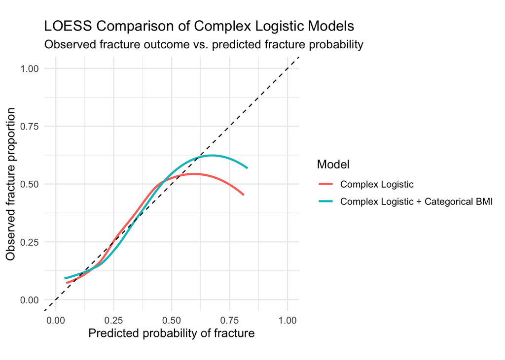

```r
loess_compare = bone_train %>%
  mutate(
    fracture_num = if_else(fracture == "Yes", 1, 0),

    `Complex Logistic` = predict(
      complex_model,
      type = "response"
    ),

    `Complex Logistic + Categorical BMI` = predict(
      complex_cat_bmi_model,
      type = "response"
    )
  ) %>%
  dplyr::select(
    fracture_num,
    `Complex Logistic`,
    `Complex Logistic + Categorical BMI`
  ) %>%
  tidyr::pivot_longer(
    cols = -fracture_num,
    names_to = "Model",
    values_to = "Predicted_Probability"
  )


# LOESS plot
loess_compare %>%
  ggplot(
    aes(
      x = Predicted_Probability,
      y = fracture_num,
      color = Model
    )
  ) +
  geom_smooth(
    method = "loess",
    se = FALSE,
    span = 0.8,
    linewidth = 1
  ) +
  geom_abline(
    intercept = 0,
    slope = 1,
    linetype = 2
  ) +
  labs(
    title = "LOESS Comparison of Complex Logistic Models",
    subtitle = "Observed fracture outcome vs. predicted fracture probability",
    x = "Predicted probability of fracture",
    y = "Observed fracture proportion",
    color = "Model"
  ) +
  coord_equal(
    xlim = c(0, 1),
    ylim = c(0, 1)
  ) +
  theme_minimal(base_size = 12)
```

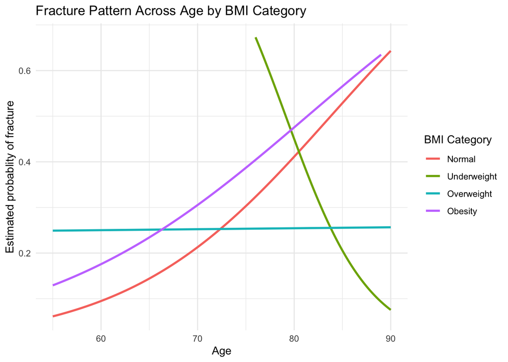

```r
# to see whether cat BMI changes the age relationship to justify the interaction term in the complex cat bmi model
bone_train %>%
  mutate(
    fracture_num = if_else(fracture == "Yes", 1, 0)
  ) %>%
  ggplot(
    aes(
      x = age,
      y = fracture_num,
      color = bmi_categorical
    )
  ) +
  geom_smooth(
    method = "glm",
    method.args = list(
      family = binomial(link = "logit")
    ),
    se = FALSE,
  ) +
  labs(
    title = "Fracture Pattern Across Age by BMI Category",
    x = "Age",
    y = "Estimated probablity of fracture",
    color = "BMI Category"
  ) +
  theme_minimal()
```

Normal BMI: fracture probability increases noticeably with age. Obesity: also shows an increasing fracture probability with age, with a somewhat higher estimated risk than normal BMI through much of the age range. Overweight: the curve is nearly flat around 25%, suggesting little age effect within that group. Underweight: the curve decreases sharply with age, but I would be very cautious interpreting this. It likely reflects a small number of underweight observations, especially at older ages.

So visually, the age effect does appear to differ across BMI categories. That gives you some justification to test an interaction:

## new complex model with cat bmi and age

```r
complex_cat_bmi_2 = glm(
  fracture ~
    age * bmi_categorical +
    priorfrac +
    momfrac +
    armassist +
    smoke +
    premeno +
    raterisk +
    bonemed,
  data = bone_train,
  family = binomial(link = "logit")
)

summary(complex_cat_bmi_2)
```

```
##
## Call:
## glm(formula = fracture ~ age * bmi_categorical + priorfrac +
##     momfrac + armassist + smoke + premeno + raterisk + bonemed,
##     family = binomial(link = "logit"), data = bone_train)
##
## Coefficients:
##                                Estimate Std. Error z value Pr(>|z|)
## (Intercept)                    -8.54855    2.00142  -4.271 1.94e-05 ***
## age                             0.08923    0.02707   3.296 0.000982 ***
## bmi_categoricalUnderweight     26.01759   19.72412   1.319 0.187144
## bmi_categoricalOverweight       7.51202    2.56868   2.924 0.003450 **
## bmi_categoricalObesity          2.28480    2.77614   0.823 0.410501
## priorfracYes                    0.73745    0.29605   2.491 0.012740 *
## momfracYes                      0.86295    0.37888   2.278 0.022750 *
## armassistYes                    0.30381    0.29184   1.041 0.297874
## smokeYes                       -0.03273    0.54222  -0.060 0.951863
## premenoYes                      0.23045    0.33583   0.686 0.492578
## rateriskSame                    0.42571    0.34000   1.252 0.210539
## rateriskGreater                 0.72396    0.36638   1.976 0.048155 *
## bonemedYes                      0.26166    0.31753   0.824 0.409913
## age:bmi_categoricalUnderweight -0.32838    0.23942  -1.372 0.170201
## age:bmi_categoricalOverweight  -0.10471    0.03601  -2.908 0.003640 **
## age:bmi_categoricalObesity     -0.02457    0.03908  -0.629 0.529601
## ---
## Signif. codes:  0 '***' 0.001 '**' 0.01 '*' 0.05 '.' 0.1 ' ' 1
##
## (Dispersion parameter for binomial family taken to be 1)
##
##     Null deviance: 419.52  on 373  degrees of freedom
## Residual deviance: 366.54  on 358  degrees of freedom
## AIC: 398.54
##
## Number of Fisher Scoring iterations: 4
```

```r
AIC(complex_cat_bmi_2)
```

```
## [1] 398.5441
```

```r
#compare with other model
anova(
  complex_cat_bmi_model,
  complex_cat_bmi_2,
  test = "Chisq"
)
```

|  | Resid. Df | Resid. Dev | Df | Deviance | Pr(>Chi) |
| --- | --- | --- | --- | --- | --- |
| 1 | 357 | 369.5712 | NA | NA | NA |
| 2 | 358 | 366.5441 | -1 | 3.027131 | NA |

```r
AIC(
  complex_cat_bmi_model,
  complex_cat_bmi_2
)
```

|  | df | AIC |
| --- | --- | --- |
| complex_cat_bmi_model | 17 | 403.5712 |
| complex_cat_bmi_2 | 16 | 398.5441 |

```r
# to check the pattern
bone_train %>%
  count(bmi_categorical, fracture)
```

| bmi_categorical | fracture | n |
| --- | --- | --- |
| Normal | No | 109 |
| Normal | Yes | 33 |
| Underweight | No | 5 |
| Underweight | Yes | 2 |
| Overweight | No | 89 |
| Overweight | Yes | 30 |
| Obesity | No | 78 |
| Obesity | Yes | 28 |

The age–fracture relationship appeared to differ somewhat across BMI categories, particularly among normal-weight, overweight, and obese women. However, the underweight group contained only seven observations, making its fitted curve highly unstable. Therefore, any apparent interaction involving the underweight category was interpreted cautiously

## combining underwegiht & normal for the interaction model

```r
bone_train = bone_train %>%
  mutate(
    bmi_cat2 = case_when(
      bmi < 25 ~ "Under/Normal",
      bmi < 30 ~ "Overweight",
      TRUE ~ "Obesity"
    ),
    bmi_cat2 = factor(
      bmi_cat2,
      levels = c("Under/Normal", "Overweight", "Obesity")
    )
  )

#test
bone_test = bone_test %>%
  mutate(
    bmi_cat2 = case_when(
      bmi < 25 ~ "Under/Normal",
      bmi < 30 ~ "Overweight",
      TRUE ~ "Obesity"
    ),
    bmi_cat2 = factor(
      bmi_cat2,
      levels = c(
        "Under/Normal",
        "Overweight",
        "Obesity"
      )
    )
  )

#new interaction model
complex_bmi_3 = glm(
  fracture ~
    age * bmi_cat2 +
    priorfrac +
    momfrac +
    armassist +
    smoke +
    premeno +
    raterisk +
    bonemed,
  data = bone_train,
  family = binomial
)

summary(complex_bmi_3)
```

```
##
## Call:
## glm(formula = fracture ~ age * bmi_cat2 + priorfrac + momfrac +
##     armassist + smoke + premeno + raterisk + bonemed, family = binomial,
##     data = bone_train)
##
## Coefficients:
##                         Estimate Std. Error z value Pr(>|z|)
## (Intercept)            -7.421180   1.854588  -4.002 6.29e-05 ***
## age                     0.072665   0.024961   2.911  0.00360 **
## bmi_cat2Overweight      6.413519   2.450055   2.618  0.00885 **
## bmi_cat2Obesity         1.099287   2.665140   0.412  0.68000
## priorfracYes            0.698206   0.292798   2.385  0.01710 *
## momfracYes              0.828142   0.375178   2.207  0.02729 *
## armassistYes            0.333342   0.290321   1.148  0.25089
## smokeYes               -0.168866   0.536365  -0.315  0.75289
## premenoYes              0.229536   0.334501   0.686  0.49258
## rateriskSame            0.466645   0.337091   1.384  0.16626
## rateriskGreater         0.742376   0.363697   2.041  0.04123 *
## bonemedYes              0.236511   0.313865   0.754  0.45112
## age:bmi_cat2Overweight -0.088581   0.034265  -2.585  0.00973 **
## age:bmi_cat2Obesity    -0.007336   0.037474  -0.196  0.84479
## ---
## Signif. codes:  0 '***' 0.001 '**' 0.01 '*' 0.05 '.' 0.1 ' ' 1
##
## (Dispersion parameter for binomial family taken to be 1)
##
##     Null deviance: 419.52  on 373  degrees of freedom
## Residual deviance: 370.71  on 360  degrees of freedom
## AIC: 398.71
##
## Number of Fisher Scoring iterations: 4
```

```r
AIC(complex_bmi_3)
```

```
## [1] 398.7079
```

```r
#compare with other model
anova(
  complex_cat_bmi_model,
  complex_cat_bmi_2,
  complex_bmi_3,
  test = "Chisq"
)
```

|  | Resid. Df | Resid. Dev | Df | Deviance | Pr(>Chi) |
| --- | --- | --- | --- | --- | --- |
| 1 | 357 | 369.5712 | NA | NA | NA |
| 2 | 358 | 366.5441 | -1 | 3.027131 | NA |
| 3 | 360 | 370.7079 | -2 | -4.163887 | 0.1246876 |

```r
AIC(
  complex_cat_bmi_model,
  complex_cat_bmi_2,
  complex_bmi_3
)
```

|  | df | AIC |
| --- | --- | --- |
| complex_cat_bmi_model | 17 | 403.5712 |
| complex_cat_bmi_2 | 16 | 398.5441 |
| complex_bmi_3 | 14 | 398.7079 |

FROM THIS: use complex_bmi_interaction3 –> it has essentially the same AIC; it uses fewer parameters, 14 vs. 16; it avoids trying to estimate separate interaction effects using only 7 underweight women; it should therefore be more stable and easier to defend.

We initially modeled BMI using four standard categories and included an age-by-BMI interaction. Because only seven women were underweight, this category produced unstable estimates. We therefore combined underweight and normal BMI. The reduced three-category interaction model had nearly identical AIC to the four-category model (398.71 versus 398.54) while using fewer parameters, so the more parsimonious specification was preferred

## evulate complex model 3 on same validation/test set

```r
complex_bmi_prediction3 = bone_test %>%
  mutate(
    .pred_Yes = predict(
      complex_bmi_3,
      newdata = bone_test,
      type = "response"
    )
  )

#check AUROC
complex_bmi_auc3 = yardstick::roc_auc_vec(
  complex_bmi_prediction3$fracture,
  complex_bmi_prediction3$.pred_Yes,
  event_level = "second"
)

complex_bmi_auc3
```

```
## [1] 0.6662234
```

## LDA model

predictors need to numeric so need to dummy code the same categorical predictors from additive model

```r
library(MASS)
library(discrim)
#LDA recipe
lda_recipe = recipe(
  fracture ~ age + height + priorfrac + momfrac +
    armassist + smoke + raterisk + bonemed,
  data = bone_train
) %>%
  step_dummy(all_nominal_predictors())

# specify LDA
lda_spec = discrim_linear() %>%
  set_engine("MASS") %>%
  set_mode("classification")


#workflow
lda_workflow = workflow() %>%
  add_recipe(lda_recipe) %>%
  add_model(lda_spec)

lda_fit = fit(
  lda_workflow,
  data = bone_train
)

#predict on probabilities on the validation data
lda_prediction = predict(
  lda_fit,
  new_data = bone_test,
  type = "prob"
) %>%
  bind_cols(
    bone_test %>%  dplyr::select(fracture)
  )

#check results
head(lda_prediction)
```

| .pred_No | .pred_Yes | fracture |
| --- | --- | --- |
| 0.8659227 | 0.1340773 | No |
| 0.2642458 | 0.7357542 | No |
| 0.8332791 | 0.1667209 | No |
| 0.5031901 | 0.4968099 | No |
| 0.5290651 | 0.4709349 | No |
| 0.7506095 | 0.2493905 | No |

```r
#temporarily using 0.50 threshold for prediction
lda_prediction = lda_prediction %>%
  mutate(
    .pred_class = factor(
      if_else(.pred_Yes >= 0.50, "Yes", "No"),
      levels = c("No", "Yes")
    )
  )

#check metrics
lda_metrics = tibble(
  Model = "LDA",
  Threshold = 0.50,

  Sensitivity = yardstick::sens_vec(
    lda_prediction$fracture,
    lda_prediction$.pred_class,
    event_level = "second"
  ),

  Specificity = yardstick::spec_vec(
    lda_prediction$fracture,
    lda_prediction$.pred_class,
    event_level = "second"
  ),

  PPV = yardstick::ppv_vec(
    lda_prediction$fracture,
    lda_prediction$.pred_class,
    event_level = "second"
  ),

  NPV = yardstick::npv_vec(
    lda_prediction$fracture,
    lda_prediction$.pred_class,
    event_level = "second"
  ),

  Prevalence = mean(
    lda_prediction$fracture == "Yes"
  ),

  AUROC = yardstick::roc_auc_vec(
    lda_prediction$fracture,
    lda_prediction$.pred_Yes,
    event_level = "second"
  )
)

lda_metrics
```

| Model | Threshold | Sensitivity | Specificity | PPV | NPV | Prevalence | AUROC |
| --- | --- | --- | --- | --- | --- | --- | --- |
| LDA | 0.5 | 0.21875 | 0.9148936 | 0.4666667 | 0.7747748 | 0.2539683 | 0.7205785 |

```r
bind_rows(
  baseline_metrics,
  complex_metrics,
  lda_metrics
)
```

| Model | Threshold | Sensitivity | Specificity | PPV | NPV | Prevalence | AUROC |
| --- | --- | --- | --- | --- | --- | --- | --- |
| Additive Logistic | 0.5 | 0.21875 | 0.9361702 | 0.5384615 | 0.7787611 | 0.2539683 | 0.7232380 |
| Complex Logistic | 0.5 | 0.18750 | 0.9574468 | 0.6000000 | 0.7758621 | 0.2539683 | 0.7175864 |
| LDA | 0.5 | 0.21875 | 0.9148936 | 0.4666667 | 0.7747748 | 0.2539683 | 0.7205785 |

So far, none of the models is clearly dominating. The additive logistic model still has the best AUROC by a small amount.

LDA produced discrimination similar to the logistic models, with an AUROC of 0.721. At a 0.50 threshold, its sensitivity remained low at 21.9%, while specificity was high at 91.5%

## QDA

```r
qda_recipe = recipe(
  fracture ~ age + height + priorfrac + momfrac +
    armassist + smoke + raterisk + bonemed,
  data = bone_train
) %>%
  step_dummy(all_nominal_predictors())

#specify QDA
qda_spec = discrim_quad() %>%
  set_engine("MASS") %>%
  set_mode("classification")

#workflow
qda_workflow = workflow() %>%
  add_recipe(qda_recipe) %>%
  add_model(qda_spec)

#fit the model
qda_fit = fit(
  qda_workflow,
  data = bone_train
)

#predict on the validation/test set
qda_prediction = predict(
  qda_fit,
  new_data = bone_test,
  type = "prob"
) %>%
  bind_cols(
    fracture = bone_test$fracture
  )

#creating 0.50 class predictions
qda_prediction = qda_prediction %>%
  mutate(
    .pred_class = factor(
      if_else(.pred_Yes >= 0.50, "Yes", "No"),
      levels = c("No", "Yes")
    )
  )

#calculate metrics
qda_metrics = tibble(
  Model = "QDA",
  Threshold = 0.50,

  Sensitivity = yardstick::sens_vec(
    qda_prediction$fracture,
    qda_prediction$.pred_class,
    event_level = "second"
  ),

  Specificity = yardstick::spec_vec(
    qda_prediction$fracture,
    qda_prediction$.pred_class,
    event_level = "second"
  ),

  PPV = yardstick::ppv_vec(
    qda_prediction$fracture,
    qda_prediction$.pred_class,
    event_level = "second"
  ),

  NPV = yardstick::npv_vec(
    qda_prediction$fracture,
    qda_prediction$.pred_class,
    event_level = "second"
  ),

  Prevalence = mean(
    qda_prediction$fracture == "Yes"
  ),

  AUROC = yardstick::roc_auc_vec(
    qda_prediction$fracture,
    qda_prediction$.pred_Yes,
    event_level = "second"
  )
)

qda_metrics
```

| Model | Threshold | Sensitivity | Specificity | PPV | NPV | Prevalence | AUROC |
| --- | --- | --- | --- | --- | --- | --- | --- |
| QDA | 0.5 | 0.34375 | 0.8510638 | 0.44 | 0.7920792 | 0.2539683 | 0.7145944 |

```r
#compare all four
bind_rows(
  baseline_metrics,
  complex_metrics,
  lda_metrics,
  qda_metrics
)
```

| Model | Threshold | Sensitivity | Specificity | PPV | NPV | Prevalence | AUROC |
| --- | --- | --- | --- | --- | --- | --- | --- |
| Additive Logistic | 0.5 | 0.21875 | 0.9361702 | 0.5384615 | 0.7787611 | 0.2539683 | 0.7232380 |
| Complex Logistic | 0.5 | 0.18750 | 0.9574468 | 0.6000000 | 0.7758621 | 0.2539683 | 0.7175864 |
| LDA | 0.5 | 0.21875 | 0.9148936 | 0.4666667 | 0.7747748 | 0.2539683 | 0.7205785 |
| QDA | 0.5 | 0.34375 | 0.8510638 | 0.4400000 | 0.7920792 | 0.2539683 | 0.7145944 |

QDA is catching more true fracture cases, but at the cost of more false positives

QDA improved sensitivity compared with the logistic and LDA models, identifying about 34% of fracture cases at the 0.50 threshold. However, this came with lower specificity and a slightly lower AUROC. This illustrates the tradeoff between sensitivity and specificity and suggests that threshold selection will be important

## Random Forest

need to use all the available baseline predictors

```r
rf_recipe = recipe(
  fracture ~ age + height + weight + bmi + fracscore +
    priorfrac + premeno + momfrac + armassist +
    smoke + raterisk + bonemed,
  data = bone_train
)

#specify the model
rf_spec = rand_forest(
  mtry = tune(),
  min_n = tune(),
  trees = 1000
) %>%
  set_engine("ranger") %>%
  set_mode("classification")

#workflow
rf_workflow = workflow() %>%
  add_recipe(rf_recipe) %>%
  add_model(rf_spec)

# 5 CV
set.seed(1234)
rf_folds = vfold_cv(
  bone_train,
  v = 5,
  strata = fracture
)

# tune the model using AUROC
set.seed(1234)

rf_tune = tune_grid(
  rf_workflow,
  resamples = rf_folds,
  grid = 20,
  metrics = metric_set(roc_auc)
)
```

```
## i Creating pre-processing data to finalize unknown parameter: mtry
```

```r
#best settings
show_best(
  rf_tune,
  metric = "roc_auc"
)
```

| mtry | min_n | .metric | .estimator | mean | n | std_err | .config |
| --- | --- | --- | --- | --- | --- | --- | --- |
| 1 | 24 | roc_auc | binary | 0.6888631 | 5 | 0.04360702 | Preprocessor1_Model02 |
| 10 | 20 | roc_auc | binary | 0.6877495 | 5 | 0.02860090 | Preprocessor1_Model18 |
| 12 | 30 | roc_auc | binary | 0.6864557 | 5 | 0.03262683 | Preprocessor1_Model20 |
| 11 | 10 | roc_auc | binary | 0.6863958 | 5 | 0.03243186 | Preprocessor1_Model19 |
| 5 | 22 | roc_auc | binary | 0.6858858 | 5 | 0.03132281 | Preprocessor1_Model10 |

```r
rf_best = select_best(
  rf_tune,
  metric = "roc_auc"
)

rf_best
```

| mtry | min_n | .config |
| --- | --- | --- |
| 1 | 24 | Preprocessor1_Model02 |

best settings re = 0.688-0.684 mtry = 1 min_n = 24

## refit the final RF on the training set

```r
final_rf_workflow =  finalize_workflow(
  rf_workflow,
  rf_best
)

final_rf_fit = fit(
  final_rf_workflow,
  data = bone_train
)
```

## prediction on test set

```r
rf_prediction = predict(
  final_rf_fit,
  new_data = bone_test,
  type = "prob"
) %>%
  bind_cols(
    fracture = bone_test$fracture
  )

head(rf_prediction)
```

| .pred_No | .pred_Yes | fracture |
| --- | --- | --- |
| 0.8438895 | 0.1561105 | No |
| 0.5351164 | 0.4648836 | No |
| 0.7980314 | 0.2019686 | No |
| 0.5577403 | 0.4422597 | No |
| 0.6026607 | 0.3973393 | No |
| 0.7715278 | 0.2284722 | No |

```r
# use temporary 0.50 threshold
rf_prediction = rf_prediction %>%
  mutate(
    .pred_class = factor(
      if_else(.pred_Yes >= 0.50, "Yes", "No"),
      levels = c("No", "Yes")
    )
  )


#Calculating RF metrics
rf_metrics = tibble(
  Model = "Random Forest",
  Threshold = 0.50,

  Sensitivity = yardstick::sens_vec(
    rf_prediction$fracture,
    rf_prediction$.pred_class,
    event_level = "second"
  ),

  Specificity = yardstick::spec_vec(
    rf_prediction$fracture,
    rf_prediction$.pred_class,
    event_level = "second"
  ),

  PPV = yardstick::ppv_vec(
    rf_prediction$fracture,
    rf_prediction$.pred_class,
    event_level = "second"
  ),

  NPV = yardstick::npv_vec(
    rf_prediction$fracture,
    rf_prediction$.pred_class,
    event_level = "second"
  ),

  Prevalence = mean(
    rf_prediction$fracture == "Yes"
  ),

  AUROC = yardstick::roc_auc_vec(
    rf_prediction$fracture,
    rf_prediction$.pred_Yes,
    event_level = "second"
  )
)

rf_metrics
```

| Model | Threshold | Sensitivity | Specificity | PPV | NPV | Prevalence | AUROC |
| --- | --- | --- | --- | --- | --- | --- | --- |
| Random Forest | 0.5 | 0 | 1 | NaN | 0.7460317 | 0.2539683 | 0.6994681 |

```r
#combine everything
model_comparison_05 <- bind_rows(
  baseline_metrics,
  complex_metrics,
  lda_metrics,
  qda_metrics,
  rf_metrics
)

model_comparison_05
```

| Model | Threshold | Sensitivity | Specificity | PPV | NPV | Prevalence | AUROC |
| --- | --- | --- | --- | --- | --- | --- | --- |
| Additive Logistic | 0.5 | 0.21875 | 0.9361702 | 0.5384615 | 0.7787611 | 0.2539683 | 0.7232380 |
| Complex Logistic | 0.5 | 0.18750 | 0.9574468 | 0.6000000 | 0.7758621 | 0.2539683 | 0.7175864 |
| LDA | 0.5 | 0.21875 | 0.9148936 | 0.4666667 | 0.7747748 | 0.2539683 | 0.7205785 |
| QDA | 0.5 | 0.34375 | 0.8510638 | 0.4400000 | 0.7920792 | 0.2539683 | 0.7145944 |
| Random Forest | 0.5 | 0.00000 | 1.0000000 | NaN | 0.7460317 | 0.2539683 | 0.6994681 |

```r
#checking if RF has abilities to ranking ability
summary(rf_prediction$.pred_Yes)
```

```
##    Min. 1st Qu.  Median    Mean 3rd Qu.    Max.
##  0.1191  0.1795  0.2270  0.2492  0.3050  0.4963
```

```r
max(rf_prediction$.pred_Yes)
```

```
## [1] 0.4962918
```

Your random forest’s largest predicted fracture probability is only 0.496, so at a threshold of 0.50 it literally cannot classify anyone as “Yes” thats why PPV = NaN

At the default 0.50 threshold, the random forest classified all validation observations as non-fractures, yielding 0% sensitivity and 100% specificity. However, its AUROC was 0.699, indicating that the model still had some ability to rank fracture risk. This suggests that 0.50 was an inappropriate threshold for this model.

## inspect lower thresholds

```r
#creating function for any prediction df
threshold_metrics = function(data, threshold) {

  pred_class = factor(
    if_else(data$.pred_Yes >= threshold, "Yes", "No"),
    levels = c("No", "Yes")
  )

  tibble(
    Threshold = threshold,
    Sensitivity = yardstick::sens_vec(
      data$fracture,
      pred_class,
      event_level = "second"
    ),
    Specificity = yardstick::spec_vec(
      data$fracture,
      pred_class,
      event_level = "second"
    ),
    PPV = yardstick::ppv_vec(
      data$fracture,
      pred_class,
      event_level = "second"
    ),
    NPV = yardstick::npv_vec(
      data$fracture,
      pred_class,
      event_level = "second"
    )
  )
}

threshold_grid = seq(0.10, 0.50, by = 0.05)
#threshold_grid = seq(0.10, 0.50, by = 0.01)

rf_thresholds = purrr::map_dfr(
  threshold_grid,
  ~ threshold_metrics(rf_prediction, .x)
)

rf_thresholds
```

| Threshold | Sensitivity | Specificity | PPV | NPV |
| --- | --- | --- | --- | --- |
| 0.10 | 1.00000 | 0.0000000 | 0.2539683 | NaN |
| 0.15 | 1.00000 | 0.1276596 | 0.2807018 | 1.0000000 |
| 0.20 | 0.87500 | 0.4574468 | 0.3544304 | 0.9148936 |
| 0.25 | 0.65625 | 0.7021277 | 0.4285714 | 0.8571429 |
| 0.30 | 0.37500 | 0.7872340 | 0.3750000 | 0.7872340 |
| 0.35 | 0.21875 | 0.8617021 | 0.3500000 | 0.7641509 |
| 0.40 | 0.12500 | 0.9255319 | 0.3636364 | 0.7565217 |
| 0.45 | 0.06250 | 0.9680851 | 0.4000000 | 0.7520661 |
| 0.50 | 0.00000 | 1.0000000 | NaN | 0.7460317 |

The default 0.50 threshold was inappropriate for the random forest because all predicted fracture probabilities were below 0.50. Lower thresholds were evaluated, and a threshold around 0.24–0.25 provided a more balanced sensitivity-specificity tradeoff.

## choosing thresholds for other models

```r
threshold_grid = seq(0.10, 0.50, by = 0.01)

additive_thresholds = purrr::map_dfr(
  threshold_grid,
  ~ threshold_metrics(baseline_prediction, .x)
)

complex_thresholds = purrr::map_dfr(
  threshold_grid,
  ~ threshold_metrics(complex_prediction, .x)
)

complex_cat_bmi_thresholds = purrr::map_dfr(
  threshold_grid,
  ~ threshold_metrics(complex_cat_bmi_prediction, .x)
)

complex_cat_bmi_thresholds_3 = purrr::map_dfr(
  threshold_grid,
  ~ threshold_metrics(
    complex_bmi_prediction3,
    .x
  )
)

lda_thresholds = purrr::map_dfr(
  threshold_grid,
  ~ threshold_metrics(lda_prediction, .x)
)

qda_thresholds = purrr::map_dfr(
  threshold_grid,
  ~ threshold_metrics(qda_prediction, .x)
)

rf_thresholds = purrr::map_dfr(
  threshold_grid,
  ~ threshold_metrics(rf_prediction, .x)
)
```

## filter each to the senstivity range –> because sens matters more than spec here

```r
additive_thresholds %>%
  filter(Sensitivity >= 0.65, Sensitivity <= 0.75) %>%
  arrange(desc(Specificity))
```

| Threshold | Sensitivity | Specificity | PPV | NPV |
| --- | --- | --- | --- | --- |
| 0.21 | 0.6875 | 0.6702128 | 0.4150943 | 0.8630137 |
| 0.20 | 0.7500 | 0.6382979 | 0.4137931 | 0.8823529 |
| 0.19 | 0.7500 | 0.5957447 | 0.3870968 | 0.8750000 |

```r
complex_thresholds %>%
  filter(Sensitivity >= 0.65, Sensitivity <= 0.75) %>%
  arrange(desc(Specificity))
```

| Threshold | Sensitivity | Specificity | PPV | NPV |
| --- | --- | --- | --- | --- |
| 0.22 | 0.65625 | 0.6808511 | 0.4117647 | 0.8533333 |
| 0.21 | 0.68750 | 0.6489362 | 0.4000000 | 0.8591549 |
| 0.20 | 0.75000 | 0.6382979 | 0.4137931 | 0.8823529 |

```r
complex_cat_bmi_thresholds %>%
  filter(Sensitivity >= 0.65, Sensitivity <= 0.75) %>%
  arrange(desc(Specificity))
```

| Threshold | Sensitivity | Specificity | PPV | NPV |
| --- | --- | --- | --- | --- |
| 0.21 | 0.65625 | 0.6489362 | 0.3888889 | 0.8472222 |
| 0.20 | 0.75000 | 0.6276596 | 0.4067797 | 0.8805970 |

```r
complex_cat_bmi_thresholds_3 %>%
  filter(
    Sensitivity >= 0.65,
    Sensitivity <= 0.75
  ) %>%
  arrange(desc(Specificity))
```

| Threshold | Sensitivity | Specificity | PPV | NPV |
| --- | --- | --- | --- | --- |
| 0.21 | 0.65625 | 0.5638298 | 0.3387097 | 0.8281250 |
| 0.20 | 0.68750 | 0.4893617 | 0.3142857 | 0.8214286 |

```r
lda_thresholds %>%
  filter(Sensitivity >= 0.65, Sensitivity <= 0.75) %>%
  arrange(desc(Specificity))
```

| Threshold | Sensitivity | Specificity | PPV | NPV |
| --- | --- | --- | --- | --- |
| 0.2 | 0.6875 | 0.6595745 | 0.4074074 | 0.8611111 |

```r
qda_thresholds %>%
  filter(Sensitivity >= 0.65, Sensitivity <= 0.75) %>%
  arrange(desc(Specificity))
```

| Threshold | Sensitivity | Specificity | PPV | NPV |
| --- | --- | --- | --- | --- |
| 0.23 | 0.65625 | 0.6702128 | 0.4038462 | 0.8513514 |
| 0.22 | 0.65625 | 0.6595745 | 0.3962264 | 0.8493151 |
| 0.21 | 0.65625 | 0.6489362 | 0.3888889 | 0.8472222 |
| 0.20 | 0.71875 | 0.6276596 | 0.3965517 | 0.8676471 |
| 0.17 | 0.71875 | 0.6063830 | 0.3833333 | 0.8636364 |
| 0.18 | 0.71875 | 0.6063830 | 0.3833333 | 0.8636364 |
| 0.19 | 0.71875 | 0.6063830 | 0.3833333 | 0.8636364 |
| 0.16 | 0.71875 | 0.5851064 | 0.3709677 | 0.8593750 |

```r
rf_thresholds %>%
  filter(Sensitivity >= 0.65, Sensitivity <= 0.75) %>%
  arrange(desc(Specificity))
```

| Threshold | Sensitivity | Specificity | PPV | NPV |
| --- | --- | --- | --- | --- |
| 0.25 | 0.65625 | 0.7021277 | 0.4285714 | 0.8571429 |
| 0.24 | 0.71875 | 0.6489362 | 0.4107143 | 0.8714286 |
| 0.23 | 0.71875 | 0.6063830 | 0.3833333 | 0.8636364 |
| 0.22 | 0.75000 | 0.5638298 | 0.3692308 | 0.8688525 |

## final classes with thresholds for each model

```r
#additive model
additive_final = baseline_prediction %>%
  mutate(
    .pred_class = factor(
      if_else(.pred_Yes >= 0.21, "Yes", "No"),
      levels = c("No", "Yes")
    )
  )

additive_final_metrics = tibble(
  Model = "Additive Logistic",
  Threshold = 0.21,
  Sensitivity = yardstick::sens_vec(
    additive_final$fracture,
    additive_final$.pred_class,
    event_level = "second"
  ),
  Specificity = yardstick::spec_vec(
    additive_final$fracture,
    additive_final$.pred_class,
    event_level = "second"
  ),
  PPV = yardstick::ppv_vec(
    additive_final$fracture,
    additive_final$.pred_class,
    event_level = "second"
  ),
  NPV = yardstick::npv_vec(
    additive_final$fracture,
    additive_final$.pred_class,
    event_level = "second"
  ),
  Prevalence = mean(additive_final$fracture == "Yes"),
  AUROC = yardstick::roc_auc_vec(
    additive_final$fracture,
    additive_final$.pred_Yes,
    event_level = "second"
  )
)

additive_final_metrics
```

| Model | Threshold | Sensitivity | Specificity | PPV | NPV | Prevalence | AUROC |
| --- | --- | --- | --- | --- | --- | --- | --- |
| Additive Logistic | 0.21 | 0.6875 | 0.6702128 | 0.4150943 | 0.8630137 | 0.2539683 | 0.723238 |

```r
# complex model
complex_final = complex_prediction %>%
  mutate(
    .pred_class = factor(
      if_else(.pred_Yes >= 0.22, "Yes", "No"),
      levels = c("No", "Yes")
    )
  )

complex_final_metrics = tibble(
  Model = "Complex Logistic",
  Threshold = 0.22,
  Sensitivity = yardstick::sens_vec(
    complex_final$fracture,
    complex_final$.pred_class,
    event_level = "second"
  ),
  Specificity = yardstick::spec_vec(
    complex_final$fracture,
    complex_final$.pred_class,
    event_level = "second"
  ),
  PPV = yardstick::ppv_vec(
    complex_final$fracture,
    complex_final$.pred_class,
    event_level = "second"
  ),
  NPV = yardstick::npv_vec(
    complex_final$fracture,
    complex_final$.pred_class,
    event_level = "second"
  ),
  Prevalence = mean(complex_final$fracture == "Yes"),
  AUROC = yardstick::roc_auc_vec(
    complex_final$fracture,
    complex_final$.pred_Yes,
    event_level = "second"
  )
)

complex_final_metrics
```

| Model | Threshold | Sensitivity | Specificity | PPV | NPV | Prevalence | AUROC |
| --- | --- | --- | --- | --- | --- | --- | --- |
| Complex Logistic | 0.22 | 0.65625 | 0.6808511 | 0.4117647 | 0.8533333 | 0.2539683 | 0.7175864 |

```r
# complex cat bmi model
complex_cat_bmi_final = complex_cat_bmi_prediction %>%
  mutate(
    .pred_class = factor(
      if_else(.pred_Yes >= 0.21, "Yes", "No"),
      levels = c("No", "Yes")
    )
  )

complex_cat_bmi_final_metrics = tibble(
  Model = "Complex Categorical BMI Logistic",
  Threshold = 0.21,
  Sensitivity = yardstick::sens_vec(
    complex_cat_bmi_final$fracture,
    complex_cat_bmi_final$.pred_class,
    event_level = "second"
  ),
  Specificity = yardstick::spec_vec(
    complex_cat_bmi_final$fracture,
    complex_cat_bmi_final$.pred_class,
    event_level = "second"
  ),
  PPV = yardstick::ppv_vec(
    complex_cat_bmi_final$fracture,
    complex_cat_bmi_final$.pred_class,
    event_level = "second"
  ),
  NPV = yardstick::npv_vec(
    complex_cat_bmi_final$fracture,
    complex_cat_bmi_final$.pred_class,
    event_level = "second"
  ),
  Prevalence = mean(complex_cat_bmi_final$fracture == "Yes"),
  AUROC = yardstick::roc_auc_vec(
    complex_cat_bmi_final$fracture,
    complex_cat_bmi_final$.pred_Yes,
    event_level = "second"
  )
)

complex_cat_bmi_final_metrics
```

| Model | Threshold | Sensitivity | Specificity | PPV | NPV | Prevalence | AUROC |
| --- | --- | --- | --- | --- | --- | --- | --- |
| Complex Categorical BMI Logistic | 0.21 | 0.65625 | 0.6489362 | 0.3888889 | 0.8472222 | 0.2539683 | 0.7177527 |

```r
#complex model 3
complex_cat_bmi_final3 = complex_bmi_prediction3 %>%
  mutate(
    .pred_class = factor(
      if_else(.pred_Yes >= 0.21, "Yes", "No"),
      levels = c("No", "Yes")
    )
  )

complex_cat_bmi_final_metrics3 = tibble(
  Model = "Complex Categorical BMI Logistic with Changed Groups",
  Threshold = 0.21,
  Sensitivity = yardstick::sens_vec(
    complex_cat_bmi_final3$fracture,
    complex_cat_bmi_final3$.pred_class,
    event_level = "second"
  ),
  Specificity = yardstick::spec_vec(
    complex_cat_bmi_final3$fracture,
    complex_cat_bmi_final3$.pred_class,
    event_level = "second"
  ),
  PPV = yardstick::ppv_vec(
    complex_cat_bmi_final3$fracture,
    complex_cat_bmi_final3$.pred_class,
    event_level = "second"
  ),
  NPV = yardstick::npv_vec(
    complex_cat_bmi_final3$fracture,
    complex_cat_bmi_final3$.pred_class,
    event_level = "second"
  ),
  Prevalence = mean(complex_cat_bmi_final3$fracture == "Yes"),
  AUROC = yardstick::roc_auc_vec(
    complex_cat_bmi_final3$fracture,
    complex_cat_bmi_final3$.pred_Yes,
    event_level = "second"
  )
)

complex_cat_bmi_final_metrics3
```

| Model | Threshold | Sensitivity | Specificity | PPV | NPV | Prevalence | AUROC |
| --- | --- | --- | --- | --- | --- | --- | --- |
| Complex Categorical BMI Logistic with Changed Groups | 0.21 | 0.65625 | 0.5638298 | 0.3387097 | 0.828125 | 0.2539683 | 0.6662234 |

```r
#lda
lda_final = lda_prediction %>%
  mutate(
    .pred_class = factor(
      if_else(.pred_Yes >= 0.2, "Yes", "No"),
      levels = c("No", "Yes")
    )
  )

lda_final_metrics = tibble(
  Model = "LDA",
  Threshold = 0.2,
  Sensitivity = yardstick::sens_vec(
    lda_final$fracture,
    lda_final$.pred_class,
    event_level = "second"
  ),
  Specificity = yardstick::spec_vec(
    lda_final$fracture,
    lda_final$.pred_class,
    event_level = "second"
  ),
  PPV = yardstick::ppv_vec(
    lda_final$fracture,
    lda_final$.pred_class,
    event_level = "second"
  ),
  NPV = yardstick::npv_vec(
    lda_final$fracture,
    lda_final$.pred_class,
    event_level = "second"
  ),
  Prevalence = mean(lda_final$fracture == "Yes"),
  AUROC = yardstick::roc_auc_vec(
    lda_final$fracture,
    lda_final$.pred_Yes,
    event_level = "second"
  )
)

lda_final_metrics
```

| Model | Threshold | Sensitivity | Specificity | PPV | NPV | Prevalence | AUROC |
| --- | --- | --- | --- | --- | --- | --- | --- |
| LDA | 0.2 | 0.6875 | 0.6595745 | 0.4074074 | 0.8611111 | 0.2539683 | 0.7205785 |

```r
#qda model
qda_final = qda_prediction %>%
  mutate(
    .pred_class = factor(
      if_else(.pred_Yes >= 0.23, "Yes", "No"),
      levels = c("No", "Yes")
    )
  )

qda_final_metrics = tibble(
  Model = "QDA",
  Threshold = 0.23,
  Sensitivity = yardstick::sens_vec(
    qda_final$fracture,
    qda_final$.pred_class,
    event_level = "second"
  ),
  Specificity = yardstick::spec_vec(
    qda_final$fracture,
    qda_final$.pred_class,
    event_level = "second"
  ),
  PPV = yardstick::ppv_vec(
    qda_final$fracture,
    qda_final$.pred_class,
    event_level = "second"
  ),
  NPV = yardstick::npv_vec(
    qda_final$fracture,
    qda_final$.pred_class,
    event_level = "second"
  ),
  Prevalence = mean(qda_final$fracture == "Yes"),
  AUROC = yardstick::roc_auc_vec(
    qda_final$fracture,
    qda_final$.pred_Yes,
    event_level = "second"
  )
)

qda_final_metrics
```

| Model | Threshold | Sensitivity | Specificity | PPV | NPV | Prevalence | AUROC |
| --- | --- | --- | --- | --- | --- | --- | --- |
| QDA | 0.23 | 0.65625 | 0.6702128 | 0.4038462 | 0.8513514 | 0.2539683 | 0.7145944 |

```r
#rf model
rf_final = rf_prediction %>%
  mutate(
    .pred_class = factor(
      if_else(.pred_Yes >= 0.25, "Yes", "No"),
      levels = c("No", "Yes")
    )
  )

rf_final_metrics = tibble(
  Model = "Random Forest",
  Threshold = 0.25,
  Sensitivity = yardstick::sens_vec(
    rf_final$fracture,
    rf_final$.pred_class,
    event_level = "second"
  ),
  Specificity = yardstick::spec_vec(
    rf_final$fracture,
    rf_final$.pred_class,
    event_level = "second"
  ),
  PPV = yardstick::ppv_vec(
    rf_final$fracture,
    rf_final$.pred_class,
    event_level = "second"
  ),
  NPV = yardstick::npv_vec(
    rf_final$fracture,
    rf_final$.pred_class,
    event_level = "second"
  ),
  Prevalence = mean(rf_final$fracture == "Yes"),
  AUROC = yardstick::roc_auc_vec(
    rf_final$fracture,
    rf_final$.pred_Yes,
    event_level = "second"
  )
)

rf_final_metrics
```

| Model | Threshold | Sensitivity | Specificity | PPV | NPV | Prevalence | AUROC |
| --- | --- | --- | --- | --- | --- | --- | --- |
| Random Forest | 0.25 | 0.65625 | 0.7021277 | 0.4285714 | 0.8571429 | 0.2539683 | 0.6994681 |

## combining all the models final metrics

```r
final_model_comparison = bind_rows(
  additive_final_metrics,
  complex_final_metrics,
  complex_cat_bmi_final_metrics,
  complex_cat_bmi_final_metrics3,
  lda_final_metrics,
  qda_final_metrics,
  rf_final_metrics
)

final_model_comparison
```

| Model | Threshold | Sensitivity | Specificity | PPV | NPV | Prevalence | AUROC |
| --- | --- | --- | --- | --- | --- | --- | --- |
| Additive Logistic | 0.21 | 0.68750 | 0.6702128 | 0.4150943 | 0.8630137 | 0.2539683 | 0.7232380 |
| Complex Logistic | 0.22 | 0.65625 | 0.6808511 | 0.4117647 | 0.8533333 | 0.2539683 | 0.7175864 |
| Complex Categorical BMI Logistic | 0.21 | 0.65625 | 0.6489362 | 0.3888889 | 0.8472222 | 0.2539683 | 0.7177527 |
| Complex Categorical BMI Logistic with Changed Groups | 0.21 | 0.65625 | 0.5638298 | 0.3387097 | 0.8281250 | 0.2539683 | 0.6662234 |
| LDA | 0.20 | 0.68750 | 0.6595745 | 0.4074074 | 0.8611111 | 0.2539683 | 0.7205785 |
| QDA | 0.23 | 0.65625 | 0.6702128 | 0.4038462 | 0.8513514 | 0.2539683 | 0.7145944 |
| Random Forest | 0.25 | 0.65625 | 0.7021277 | 0.4285714 | 0.8571429 | 0.2539683 | 0.6994681 |

Additive Logistic still has the highest AUROC: 0.723 LDA is very close: 0.721 Original Complex Logistic: 0.718 First categorical-BMI complex model: about 0.718 Second categorical-BMI complex model: 0.666, which is clearly worse Random Forest: 0.699

Adding categorical BMI and age-by-BMI interaction terms did not improve out-of-sample predictive performance. One categorical-BMI model performed similarly to the original complex logistic model, while the more heavily modified version performed substantially worse. This suggests the added BMI complexity was not helpful for prediction.

And for LDA/QDA:

LDA performed nearly identically to logistic regression, while QDA offered no meaningful improvement. This suggests that allowing class-specific covariance structures did not substantially improve discrimination.

Just keep complex model without cat bmi or different bucket of bmi in the final ROC curve comparision

## ROC curve comparision

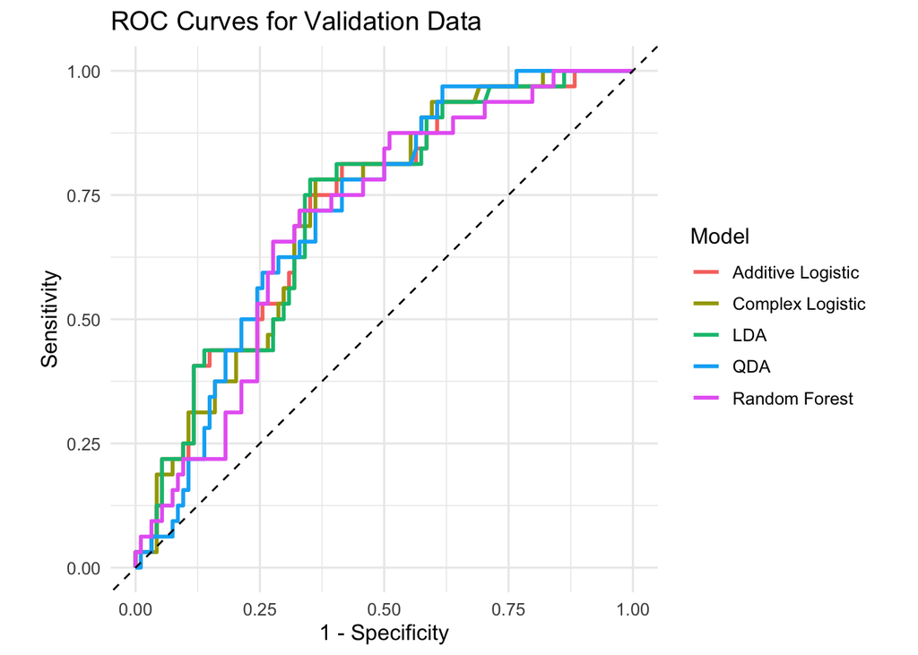

```r
roc_data = bind_rows(
  yardstick::roc_curve(
    baseline_prediction,
    truth = fracture,
    .pred_Yes,
    event_level = "second"
  ) %>%
    mutate(Model = "Additive Logistic"),

  yardstick::roc_curve(
    complex_prediction,
    truth = fracture,
    .pred_Yes,
    event_level = "second"
  ) %>%
    mutate(Model = "Complex Logistic"),


  yardstick::roc_curve(
    lda_prediction,
    truth = fracture,
    .pred_Yes,
    event_level = "second"
  ) %>%
    mutate(Model = "LDA"),

  yardstick::roc_curve(
    qda_prediction,
    truth = fracture,
    .pred_Yes,
    event_level = "second"
  ) %>%
    mutate(Model = "QDA"),

  yardstick::roc_curve(
    rf_prediction,
    truth = fracture,
    .pred_Yes,
    event_level = "second"
  ) %>%
    mutate(Model = "Random Forest")
)

#plotting it
roc_data %>%
  ggplot(
    aes(
      x = 1 - specificity,
      y = sensitivity,
      color = Model
    )
  ) +
  geom_path(linewidth = 1) +
  geom_abline(
    intercept = 0,
    slope = 1,
    linetype = 2
  ) +
  coord_equal() +
  labs(
    title = "ROC Curves for Validation Data",
    x = "1 - Specificity",
    y = "Sensitivity",
    color = "Model"
  ) +
  theme_minimal(base_size = 12)
```

All five curves are above the diagonal reference line, so all models discriminate better than random guessing. The curves are very close together, which matches the AUROCs clustered around 0.70–0.72. The additive logistic model has the highest AUROC, but only by a small margin. Random Forest does not show a clear improvement despite being more flexible.

#discussion of LDA/QDA assumptions LDA and QDA assumptions were only approximately satisfied. Several predictors were categorical, and the continuous predictors did not appear perfectly multivariate normal within fracture groups. LDA additionally assumes equal covariance matrices across groups, while QDA relaxes that requirement. Because predictive performance was similar to logistic regression, these assumption violations did not appear to produce a major practical advantage for either discriminant-analysis model